# **CIS 545 U.S. Road Accident Predictor**

##### By Antina Yeh, Norris Chen, Joyce An-Jie Wang

##### Dec 12, 2022

## Motivation

The United States has one of the highest rates of road accidents in the world, with over 40,000 fatalities and millions of injuries each year. These accidents have a devastating impact on individuals, families, and communities, and they also have a significant economic cost, with billions of dollars in medical expenses and lost productivity.

One way to address this problem is to develop a road accidents model that can help identify the factors that contribute to accidents and predict the likelihood of future accidents in different areas. This model could be used by policymakers and transportation agencies to target interventions and invest in safety measures that can prevent accidents and save lives.

The motivation for designing such a model is twofold. First, it would help to better understand the causes of road accidents and identify opportunities for intervention. By analyzing data on factors such as weather, road conditions, and road obstacles, the model could provide insights into the underlying causes of accidents and help identify interventions that can reduce their frequency.

Second, the model could be used to predict the likelihood of accidents in different areas, which could help to prioritize safety investments and allocate resources more effectively. By providing a quantitative assessment of the risk of accidents in different areas, the model could help policymakers and transportation agencies make more informed decisions about where to invest in safety measures such as improved signage, enhanced road maintenance, and driver education programs.

Overall, the motivation for designing a road accidents model is to help prevent accidents, save lives, and reduce the economic cost of accidents in the United States. By providing insights into the causes of accidents and predicting their likelihood in different areas, such a model could play a valuable role in improving road safety and protecting the public.

## **Imports**

```python
# pandas setup
import pandas as pd
import numpy as np
import nltk as nltk
nltk.download('punkt')
import seaborn as sns
import matplotlib.pyplot as plt
import plotly.graph_objects as go

#Importing all sk learn libraries we need for the project
from sklearn.preprocessing import StandardScaler
from sklearn.model_selection import train_test_split
import sklearn.metrics as metric
from sklearn.neighbors import KNeighborsClassifier
from sklearn.preprocessing import PolynomialFeatures
from sklearn.linear_model import LinearRegression as LinearRegressionSklearn
from sklearn.metrics import mean_squared_error as mse
from sklearn.linear_model import LogisticRegression
from sklearn.metrics import f1_score
from sklearn.metrics import accuracy_score
from sklearn.impute import KNNImputer
from sklearn.model_selection import GridSearchCV
from sklearn.dummy import DummyClassifier
from sklearn.ensemble import RandomForestClassifier
from sklearn.decomposition import PCA
from sklearn import tree
from sklearn.tree import DecisionTreeClassifier
```

## **U.S. Accidents (2016 - 2021) Data**

This dataset contains countrywide traffic accident records that cover 49 states of the United States happened between 2016 and 2021. The data captures the geographic location, time, and severity of accidents, as well as a variety of weather conditions and road features where those accidents occurred, which we will use as features for our machine learning modeling later in this project to predict the severity of accidents. For example, temperature, visibility of the road, presence of road obstacles (such as stops, bumps, crossing, junction, etc.), or period of a day when an accident happened. In the following section, we preprocess this dataset to allow us better extract useful information for EDA, and prepare for choosing relevant features for modeling.

**Data sources**:

1. Moosavi, Sobhan, Mohammad Hossein Samavatian, Srinivasan Parthasarathy, and Rajiv Ramnath. “[A Countrywide Traffic Accident Dataset.](https://arxiv.org/abs/1906.05409)”, 2019.
2. Moosavi, Sobhan, Mohammad Hossein Samavatian, Srinivasan Parthasarathy, Radu Teodorescu, and Rajiv Ramnath. "[Accident Risk Prediction based on Heterogeneous Sparse Data: New Dataset and Insights.](https://arxiv.org/abs/1909.09638)" In proceedings of the 27th ACM SIGSPATIAL International Conference on Advances in Geographic Information Systems, ACM, 2019.

*Link to the Kaggle dataset:* https://www.kaggle.com/datasets/sobhanmoosavi/us-accidents?fbclid=IwAR0b78zhjpAcm3WpxPdyX9lppRxY7GMDsctVvDgDHmv4m4U4VtVniWI-W88

# Load and Preprocess Data

### Import Packages and Initialize File Paths

[Link to CSV](https://drive.google.com/file/d/1yos93IC_43EqpScZJQ5p5pT9S7IkNC3S/view?usp=sharing) (need to load to run the notebook)

```python
# load the data from Google Drive
from google.colab import drive
drive.mount('/content/drive')
df = pd.read_csv("/content/drive/My Drive/US_Accidents_Dec21_updated.csv")
```

```python
# take a quick look at what the data look like
df.head()
```

|  | ID | Severity | Start_Time | End_Time | Start_Lat | Start_Lng | End_Lat | End_Lng | Distance(mi) | Description | ... | Roundabout | Station | Stop | Traffic_Calming | Traffic_Signal | Turning_Loop | Sunrise_Sunset | Civil_Twilight | Nautical_Twilight | Astronomical_Twilight |
| --- | --- | --- | --- | --- | --- | --- | --- | --- | --- | --- | --- | --- | --- | --- | --- | --- | --- | --- | --- | --- | --- |
| 0 | A-1 | 3 | 2016-02-08 00:37:08 | 2016-02-08 06:37:08 | 40.108910 | -83.092860 | 40.112060 | -83.031870 | 3.230 | Between Sawmill Rd/Exit 20 and OH-315/Olentang... | ... | False | False | False | False | False | False | Night | Night | Night | Night |
| 1 | A-2 | 2 | 2016-02-08 05:56:20 | 2016-02-08 11:56:20 | 39.865420 | -84.062800 | 39.865010 | -84.048730 | 0.747 | At OH-4/OH-235/Exit 41 - Accident. | ... | False | False | False | False | False | False | Night | Night | Night | Night |
| 2 | A-3 | 2 | 2016-02-08 06:15:39 | 2016-02-08 12:15:39 | 39.102660 | -84.524680 | 39.102090 | -84.523960 | 0.055 | At I-71/US-50/Exit 1 - Accident. | ... | False | False | False | False | False | False | Night | Night | Night | Day |
| 3 | A-4 | 2 | 2016-02-08 06:51:45 | 2016-02-08 12:51:45 | 41.062130 | -81.537840 | 41.062170 | -81.535470 | 0.123 | At Dart Ave/Exit 21 - Accident. | ... | False | False | False | False | False | False | Night | Night | Day | Day |
| 4 | A-5 | 3 | 2016-02-08 07:53:43 | 2016-02-08 13:53:43 | 39.172393 | -84.492792 | 39.170476 | -84.501798 | 0.500 | At Mitchell Ave/Exit 6 - Accident. | ... | False | False | False | False | False | False | Day | Day | Day | Day |

5 rows × 47 columns

## 1. Change Data Types

Looking at the info table below, we can see that we will need to covert the data types of some relevant columns so that we can use them for our EDA and modeling later. We are going to covert:

1. Start_Time and End_Time columns to datetime object
2. Weather_Condition and Description columns to string

```python
# take a look at the data type of each feature
df.info()
```

```
<class 'pandas.core.frame.DataFrame'>
RangeIndex: 2845342 entries, 0 to 2845341
Data columns (total 47 columns):
 #   Column                 Dtype
---  ------                 -----
 0   ID                     object
 1   Severity               int64
 2   Start_Time             object
 3   End_Time               object
 4   Start_Lat              float64
 5   Start_Lng              float64
 6   End_Lat                float64
 7   End_Lng                float64
 8   Distance(mi)           float64
 9   Description            object
```

[output cut: 39 more lines]

```python
# convert Weather_Condition and Description to string type
df['Weather_Condition'] = df['Weather_Condition'].astype(str)
df['Description'] = df['Description'].astype(str)

# convert Start_Time and End_Time to datetime object
df['Start_Time'] = pd.to_datetime(df['Start_Time'])
df['End_Time'] = pd.to_datetime(df['End_Time'])
```

```python
# from here we see the data types are changed
df.info()
```

```
<class 'pandas.core.frame.DataFrame'>
RangeIndex: 2845342 entries, 0 to 2845341
Data columns (total 47 columns):
 #   Column                 Dtype
---  ------                 -----
 0   ID                     object
 1   Severity               int64
 2   Start_Time             datetime64[ns]
 3   End_Time               datetime64[ns]
 4   Start_Lat              float64
 5   Start_Lng              float64
 6   End_Lat                float64
 7   End_Lng                float64
 8   Distance(mi)           float64
 9   Description            object
```

[output cut: 39 more lines]

## 2. Drop Duplicates

Now, we want to first drop duplicate rows from our dataset if any.

```python
# drop any duplicate rows
df = df.drop_duplicates()
```

## 3. Drop Irrelevant Columns and Rename Columns

Since all of the accidents recorded in this dataset happened in the U.S., the Country column is not informative for our EDA or modeling. We are going to drop it. The number columm that refers to the street number where an accident occurred doesn't seem to provide any information in predicting the severity of accidents, so we will also procede to drop the column. In addition, we are going to drop Civil_Twilight, Nautical_Twilight, and Astronomical_Twilight columns, which store day/night information using different definitions, because we have another equivalent and more straighforward column Sunset_Sunrise that we can utilize in our EDA. We also dropped the features Airport_code and Timezone because the same information relating to location of the accident can be found using the column City instead. We also dropped multiple road feature columns because we discovered that all of the features had a false value, thus it was not meaningful to keep the columns. Lastly, we dropped the columns weather_timestamp and description because both weather_timestamp and description were columns that were used to create additional columns for the dataset in the first place. For instance, the weather_timestamp allowed the dataset to find the weather at the time of the accident, and the column description allowed the dataset to generate columns such as accident location. Since we have new columns that better represent the original data, we can drop these rows as well.

```python
# drop irrelevant columns
df = df.drop(columns=['Country', 'Number', 'Civil_Twilight', 'Nautical_Twilight', \
                      'Astronomical_Twilight',"Airport_Code", "Timezone", "Side", \
                      "Roundabout", "Bump", "Give_Way", "No_Exit", "Traffic_Calming",\
                      "Turning_Loop", "Weather_Timestamp", "Description"])
```

Furthermore, we rename the following columns to remove the measuring units from the columm names.

```python
# rename the numeric columns
df = df.rename(columns={"Distance(mi)": "Distance",\
                        "Temperature(F)": "Temperature", \
                        "Wind_Chill(F)": "Wind_Chill", \
                        "Humidity(%)": "Humidity",\
                        "Pressure(in)": "Pressure",\
                        "Visibility(mi)": "Visibility",\
                        "Wind_Speed(mph)": "Wind_Speed",\
                        "Precipitation(in)": "Precipitation",
                        })
```

## 4. Round Up Float Type Data

For the easeness of reading data, we round up all float type data to two decimals.

```python
# roud latitude, longitude, and distance columns to two decimals
df['Start_Lat'] = df['Start_Lat'].round(2)
df['Start_Lng'] = df['Start_Lng'].round(2)
df['End_Lat'] = df['End_Lat'].round(2)
df['End_Lng'] = df['End_Lng'].round(2)
df['Distance'] = df['Distance'].round(2)
```

## 5. Preprocess Accident Datetime, Weather Condition, and Street

### Accident Datetime Parsing

Since we want to use the Start_Time and End_Time columns for our EDA, we need to extract the day, month, and year for each accident and calculate the duration of each accident.

```python
# extracting day, month, year, and day of a week to separate columns
df['Year'] = pd.DatetimeIndex(df['Start_Time']).year
df['Month'] = pd.DatetimeIndex(df['Start_Time']).month
df['Day'] = pd.DatetimeIndex(df['Start_Time']).day
df['Day_of_Week'] = pd.DatetimeIndex(df['Start_Time']).dayofweek + 1

# calculate accident duration using Start_Time and End_Time
df['Duration'] = df['End_Time'] - df['Start_Time']

# convert the duration to minutes
df['Duration_Minutes']=round(df['Duration']/np.timedelta64(1,'m'))
```

### Weather Condition Parsing

Looking at the weather conditions column, we see that there are 128 unique weather patterns, which is too many to perform efficient EDA and modeling on. Thus, we grouped the weather conditions into 10 large categories that well represents the different categories that the weather conditions fall in. We used nltk to tokenize the weather conditions, and matched specific keywoards to the tokenized result in order to sort the weather. For certain extreme weather such as tornado, hurricane..etc, we grouped them into the 'Other' category.

```python
# A look at the count of unique weather values.
df['Weather_Condition'].nunique()
```

```
128
```

```python
# Setting up weather condition categories
weather_features = ['Drizzle', 'Rain', 'Snow', 'Cloudy', 'Fog', 'Haze', 'Windy', 'Thunderstorm', 'Fair', 'Other']

# Function for categorizing weather conditions
def weather(content):
  token = nltk.word_tokenize(content)
  for word in token:
    if word in weather_features:
      return word
    if word == 'nan':
      return 'Fair'
    if word == 'Thunder':
      return 'Thunderstorm'
  return 'Other'

# Apply function to weather condition column to categorize weather
df['Weather_Condition'] = df['Weather_Condition'].apply(lambda x : weather(x))
```

## Sanity Check for Temperature, Precipitation and Wind Speed

One of the flaws in our dataset is that it comes with incorrectly recorded information for Temperature, Precipitation, and Wind Speed that are unusually high or low. As such, we used emperical data that suggested the highest and lowest possible temperature, precipitation, and wind speed to sense check for our dataset, and fill the columns of those data with NaN.

```python
df['Temperature'].loc[df['Temperature'] <  -70] = np.NaN
df['Temperature'].loc[df['Temperature'] >  130] = np.NaN
df['Precipitation'].loc[df['Precipitation'] <  0] = np.NaN
df['Precipitation'].loc[df['Precipitation'] >  2] = np.NaN
df['Wind_Speed'].loc[df['Wind_Speed'] <  0] = np.NaN
df['Wind_Speed'].loc[df['Wind_Speed'] >  300] = np.NaN
```

Now, we sense check again the highest and lowest values for Temperature, Precipitation, and Wind Speed.

```python
df['Temperature'].max()
```

```
129.2
```

```python
df['Temperature'].min()
```

```
-58.0
```

```python
df['Precipitation'].max()
```

```
1.99
```

```python
df['Precipitation'].min()
```

```
0.0
```

```python
df['Wind_Speed'].max()
```

```
245.1
```

```python
df['Wind_Speed'].min()
```

```
0.0
```

Imputation for EDA

### Sampling method

Before we impute, we should take this dataset to do for ml

Note: this is a different dataframe from the original one; this one is purely meant for machine learning

We actually only take a small sample here because we are only working with 40000 datapoints our first iteration. Also, we take this set before the imputation step because we want to use KNN imputation on the dataset the machine learning models will train on.

```python
#Before we impute, we should take this dataset to do for ml
#Feature management for ML model: Resizing for non-bias towards 2's
#This is ONE of the ways to deal with unbalanced DATASET, but there are other ways (ADDIND WEIGHTS DURING F1 SCORING)
bucket_1 = 10000
bucket_2 = 10000
bucket_3 = 10000
bucket_4 = 10000
df_sample_severity_1 = df.loc[df.Severity == 1].sample(bucket_1)
df_sample_severity_2 = df.loc[df.Severity == 2].sample(bucket_2)
df_sample_severity_3 = df.loc[df.Severity == 3].sample(bucket_3)
df_sample_severity_4 = df.loc[df.Severity == 4].sample(bucket_4)

df_for_ml = pd.concat([df_sample_severity_1,df_sample_severity_2 ,df_sample_severity_3 ,df_sample_severity_4], axis=0)
```

Second Iteration of machine learning dataframe. We take 25000 datapoints from each severity label to keep it a balanced dataset so the machine learning model can learn better. This is an example of under sampling for bucket 2.

We also chose 25000 because severity 1 bucket only has 25500 points. This results with a total of 100000 datapoints.

```python
bucket_1 = 25000
bucket_2 = 25000
bucket_3 = 25000
bucket_4 = 25000
df_sample_severity_1 = df.loc[df.Severity == 1].sample(bucket_1)
df_sample_severity_2 = df.loc[df.Severity == 2].sample(bucket_2)
df_sample_severity_3 = df.loc[df.Severity == 3].sample(bucket_3)
df_sample_severity_4 = df.loc[df.Severity == 4].sample(bucket_4)

df_for_ml_2 = pd.concat([df_sample_severity_1,df_sample_severity_2 ,df_sample_severity_3 ,df_sample_severity_4], axis=0)
```

### Imputation

```python
# we first take a look at how many null values in our data
df.isnull().sum()
```

```
ID                        0
Severity                  0
Start_Time                0
End_Time                  0
Start_Lat                 0
Start_Lng                 0
End_Lat                   0
End_Lng                   0
Distance                  0
Street                    2
City                    137
County                    0
State                     0
Zipcode                1319
Temperature           69285
Wind_Chill           469643
Humidity              73092
Pressure              59200
Visibility            70546
Wind_Direction        73775
Wind_Speed           157952
Precipitation        549664
Weather_Condition         0
Amenity                   0
Crossing                  0
Junction                  0
Railway                   0
Station                   0
Stop                      0
Traffic_Signal            0
Sunrise_Sunset         2867
Year                      0
Month                     0
Day                       0
Day_of_Week               0
Duration                  0
Duration_Minutes          0
dtype: int64
```

```python
#filling missing data with mean values
df['Wind_Chill'] = df['Wind_Chill'].fillna(df['Wind_Chill'].mean())
df['Humidity'] = df['Humidity'].fillna(df['Humidity'].mean())
df['Pressure'] = df['Pressure'].fillna(df['Pressure'].mean())
df['Visibility'] = df['Visibility'].fillna(df['Visibility'].mean())
df['Wind_Speed'] = df['Wind_Speed'].fillna(df['Wind_Speed'].mean())
df['Precipitation'] = df['Precipitation'].fillna(df['Precipitation'].mean())
df['Temperature'] = df['Temperature'].fillna(df['Precipitation'].mean())
```

For qualitative features that cannot be replaced with a mean, we simply dropped the null values since we can see from the cells above that the features 'Street', 'City', and 'Wind_Direction' don't have too many null values to begin with.

```python
#drop null values
df = df.dropna(subset=['Street', 'City', 'Wind_Direction'])
```

Using a cut off of 5:00am and 6:00pm to help determine 'Day' and 'Night'

```python
#change time to str for ease of computation
df['Time'] = df['Start_Time'].dt.time.astype(str)

#fill in 'day' or 'night' for missing values
mask = (df['Time'] >= '05:00') & (df['Time'] <='18:00')
df.loc[mask, 'Sunrise_Sunset'] = df.loc[mask, 'Sunrise_Sunset'].fillna('Day')
df['Sunrise_Sunset'] = df['Sunrise_Sunset'].fillna('Night')
```

```python
#confirming that there are no more null values
df.isnull().sum()
```

```
ID                   0
Severity             0
Start_Time           0
End_Time             0
Start_Lat            0
Start_Lng            0
End_Lat              0
End_Lng              0
Distance             0
Street               0
City                 0
County               0
State                0
Zipcode              0
Temperature          0
Wind_Chill           0
Humidity             0
Pressure             0
Visibility           0
Wind_Direction       0
Wind_Speed           0
Precipitation        0
Weather_Condition    0
Amenity              0
Crossing             0
Junction             0
Railway              0
Station              0
Stop                 0
Traffic_Signal       0
Sunrise_Sunset       0
Year                 0
Month                0
Day                  0
Day_of_Week          0
Duration             0
Duration_Minutes     0
Time                 0
dtype: int64
```

# Feature Engineering

### Create a New Column: Height

Looking through the environment features in our dataset, we thought the air pressure information (Pressure) would potentially give us more insight if transformed to height information when we look at the correlation between accident severity and it later. So we created a new feature Height by calculating directly from the air pressure feature using a standard conversion formula.

```python
# Convert temperature (F) to Kelvin unit (K)
df['Temperature_K'] = ((df['Temperature']-32)*5/9) + 273.15

# Find height above sea level in feet
df['Height'] = -(1.38*10**-23 * df['Temperature_K'] * np.log(df['Pressure']/29.92))/(4.8107*10**(-26)*9.81)

# Change meters to feet
df['Height'] = df['Height'] * 3.28084

# Sort the data based on height and take a sneak peak of the height info
df.sort_values(by='Height', ascending=False)
```

|  | ID | Severity | Start_Time | End_Time | Start_Lat | Start_Lng | End_Lat | End_Lng | Distance | Street | ... | Sunrise_Sunset | Year | Month | Day | Day_of_Week | Duration | Duration_Minutes | Time | Temperature_K | Height |
| --- | --- | --- | --- | --- | --- | --- | --- | --- | --- | --- | --- | --- | --- | --- | --- | --- | --- | --- | --- | --- | --- |
| 2510161 | A-2510162 | 3 | 2019-03-28 10:08:17 | 2019-03-28 10:36:29 | 34.59 | -79.12 | 34.60 | -79.10 | 1.73 | I-95 N | ... | Day | 2019 | 3 | 28 | 4 | 0 days 00:28:12 | 28.0 | 10:08:17 | 255.375742 | inf |
| 149726 | A-149727 | 2 | 2017-02-16 12:37:48 | 2017-02-16 18:37:48 | 32.74 | -86.54 | 32.72 | -86.53 | 1.08 | I-65 S | ... | Day | 2017 | 2 | 16 | 4 | 0 days 06:00:00 | 360.0 | 12:37:48 | 287.150000 | 2.013936e+05 |
| 2748825 | A-2748826 | 2 | 2017-09-05 15:22:40 | 2017-09-05 21:22:40 | 34.07 | -117.80 | 34.06 | -117.81 | 1.04 | I-10 W | ... | Day | 2017 | 9 | 5 | 2 | 0 days 06:00:00 | 360.0 | 15:22:40 | 255.375742 | 1.127614e+05 |
| 2748828 | A-2748829 | 3 | 2017-09-05 15:36:10 | 2017-09-05 21:36:10 | 34.07 | -117.78 | 34.07 | -117.79 | 0.33 | I-10 W | ... | Day | 2017 | 9 | 5 | 2 | 0 days 06:00:00 | 360.0 | 15:36:10 | 255.375742 | 1.127614e+05 |
| 2717941 | A-2717942 | 2 | 2017-12-13 16:11:15 | 2017-12-13 22:11:15 | 34.03 | -118.04 | 34.02 | -118.05 | 0.98 | I-605 S | ... | Day | 2017 | 12 | 13 | 3 | 0 days 06:00:00 | 360.0 | 16:11:15 | 300.150000 | 6.632343e+04 |
| ... | ... | ... | ... | ... | ... | ... | ... | ... | ... | ... | ... | ... | ... | ... | ... | ... | ... | ... | ... | ... | ... |
| 1344457 | A-1344458 | 2 | 2021-10-19 20:55:00 | 2021-10-19 23:00:09 | 37.44 | -122.25 | 37.43 | -122.24 | 0.55 | I-280 S | ... | Night | 2021 | 10 | 19 | 2 | 0 days 02:05:09 | 125.0 | 20:55:00 | 289.261111 | -1.879606e+04 |
| 2075543 | A-2075544 | 2 | 2020-05-27 17:39:36 | 2020-05-27 18:29:34 | 35.05 | -89.83 | 35.05 | -89.83 | 0.00 | Winchester Rd | ... | Day | 2020 | 5 | 27 | 3 | 0 days 00:49:58 | 50.0 | 17:39:36 | 300.372222 | -1.894487e+04 |
| 580465 | A-580466 | 2 | 2021-08-06 19:08:00 | 2021-08-06 22:11:31 | 37.37 | -120.94 | 37.38 | -120.94 | 0.30 | Turner Ave | ... | Day | 2021 | 8 | 6 | 5 | 0 days 03:03:31 | 184.0 | 19:08:00 | 300.927778 | -1.918915e+04 |
| 1132478 | A-1132479 | 2 | 2021-08-06 19:08:00 | 2021-08-06 23:01:36 | 37.37 | -120.94 | 37.38 | -120.94 | 0.30 | Turner Ave | ... | Day | 2021 | 8 | 6 | 5 | 0 days 03:53:36 | 234.0 | 19:08:00 | 300.927778 | -1.918915e+04 |
| 614124 | A-614125 | 2 | 2021-08-10 17:47:00 | 2021-08-10 21:14:40 | 37.81 | -120.31 | 37.81 | -120.31 | 0.07 | State Highway 49 | ... | Day | 2021 | 8 | 10 | 2 | 0 days 03:27:40 | 208.0 | 17:47:00 | 312.038889 | -1.988222e+04 |

2771431 rows × 40 columns

The following cells do a basic sanity check for the height we calculated, and there seems to be quite a few data with impossible height/air pressure values.

```python
# take a quick look at the distribution of the height column we made
df['Height'].describe()
```

```
count    2.771431e+06
mean              inf
std               NaN
min     -1.988222e+04
25%     -8.352606e+01
50%      9.308408e+01
75%      5.651443e+02
max               inf
Name: Height, dtype: float64
```

```python
# take a quick look at the lowest group of height
df.Height.quantile(0.1)
```

```
-196.29467217903053
```

```python
# take a quick look at the highest group of height
df.Height.quantile(0.99)
```

```
5119.883897186688
```

We remove data with invalid height based on:

- the lowest paved road in the U.S.: 282 ft
- the highest paved road in the U.S.: 14,130 ft

```python
#Change heights that are extremes to NaNs
df['Height'].loc[df['Height'] <  282] = np.NaN
df['Height'].loc[df['Height'] >  14130] = np.NaN
```

```python
# review the distribution of Height
df['Height'].describe()
```

```
count    1.010913e+06
mean     1.254712e+03
std      1.326986e+03
min      2.820087e+02
25%      5.016981e+02
50%      7.679920e+02
75%      1.213642e+03
max      1.257971e+04
Name: Height, dtype: float64
```

## Create a New Column: Obstacle

Since there are many different types of road features such as crossing, junction, traffic signal etc, it may be beneficial to create a seperate column that determines whether a road feature exists or not. Specifically, for the purpose of selecting road features that may have an impact on traffic accidents, we've chosen to categorize accidents that has any one of the below road features as being near an obstacle when the accident happened.

```python
#Selecting road features
df['Obstacle'] = df[['Crossing','Junction', 'Railway', 'Stop',
                     'Traffic_Signal']].any(axis=1)
#Giving it a value of 0 or 1
df[['Obstacle']] = df[['Obstacle']].astype(int)
```

## Road Features Encoding

The following cell converts categorical variables (boolean type features) that tell whether there exists certain road features in the road where an accident happened, into a binary value of 1 or 0.

```python
# convert boolean type columns to integer, which results in assigning each value to 1 or 0
df[['Amenity', 'Crossing', 'Junction', \
    'Railway', 'Station', 'Stop', \
    'Traffic_Signal']] \
    = df[['Amenity', 'Crossing', 'Junction',\
          'Railway', 'Station', 'Stop', \
          'Traffic_Signal']].astype(int)
```

### Street Parsing

Looking at the street column, there are currently too many street names to perform efficient EDA and modeling on. However, the street feature could be useful in our project since it gives insight on the type of road the accident happend on. Thus, we created a new column called Street Type that categorizes the street as either highway or local road based on the street name.

```python
#Helper arrays for categorizing streets
highways = ['Fwy', 'Expy', 'Highway', 'Hwy', 'Route']
local_roads = ['Rd', 'Ave','Blvd', 'Road']

#Function for categorizing streets as highway or local roads
def street_type(street):
  if street[:1] == 'I' or street[2:3] == '-':
    return 'Interstate'
  if street[-2:] == 'Rd' or 'St':
    return 'Local Roads'
  for highway in highways:
    if highway in street:
      return 'Interstate'
  for local in local_roads:
    if local in street:
      return 'Local Roads'
  return 'Other'

#Apply function on 'Street' column and create a new column called 'Street Type'
df['Street_Type'] = df['Street'].apply(lambda x : street_type(x))
df_categorical = df
```

## Day-Night Encoding

The Sunrise_Sunset column contains information on whether an accident happened during the day or at night. Since we want to use this column in our ML modeling, we convert it into a binary value of 1 or 0.

```python
# we assigned "Day" to 0 and "Night" to 1
def encoding(x):
  code = {"Day": 0, "Night": 1}
  return code[x]

df['Sunrise_Sunset'] = df['Sunrise_Sunset'].apply(lambda x: encoding(x))
df['Sunrise_Sunset'].sort_values()
```

```
1417241    0
1625769    0
1625762    0
1625761    0
1625760    0
          ..
1817511    1
1817508    1
1817507    1
1817534    1
0          1
Name: Sunrise_Sunset, Length: 2771431, dtype: int64
```

## Feature Engineering for the ml dataframe

This is ALL the steps from feature engineering done on the machine learning dataframe. Although we didn't want the imputed data from the original dataframe, we still want all the feature engineering and encoding done to do machine learning

```python
df_for_ml = df_for_ml.dropna(subset=['Street', 'City', 'Wind_Direction'])

df_for_ml['Time'] = df_for_ml['Start_Time'].dt.time.astype(str)

mask = (df_for_ml['Time'] >= '05:00') & (df_for_ml['Time'] <='18:00')
df_for_ml.loc[mask, 'Sunrise_Sunset'] = df_for_ml.loc[mask, 'Sunrise_Sunset'].fillna('Day')

df_for_ml['Sunrise_Sunset'] = df_for_ml['Sunrise_Sunset'].fillna('Night')

df_for_ml.loc[df_for_ml['Sunrise_Sunset'] == 'Night'][['Sunrise_Sunset', 'Time']]


# Convert temperature (F) to Kelvin unit (K)
df_for_ml['Temperature_K'] = ((df_for_ml['Temperature']-32)*5/9) + 273.15

# Find height above sea level in feet
df_for_ml['Height'] = -(1.38*10**-23 * df_for_ml['Temperature_K'] * np.log(df_for_ml['Pressure']/29.92))/(4.8107*10**(-26)*9.81)

# Change meters to feet
df_for_ml['Height'] = df_for_ml['Height'] * 3.28084

# Sort the data based on height and take a sneak peak of the height info
df_for_ml.sort_values(by='Height', ascending=False)

df_for_ml['Height'].loc[df_for_ml['Height'] <  282] = np.NaN
df_for_ml['Height'].loc[df_for_ml['Height'] >  14130] = np.NaN

#############
df_for_ml['Obstacle'] = df_for_ml[['Crossing','Junction', 'Railway', 'Stop',
                     'Traffic_Signal']].any(axis=1)
#Giving it a value of 0 or 1
df_for_ml[['Obstacle']] = df_for_ml[['Obstacle']].astype(int)

################
df_for_ml[['Amenity','Crossing', 'Junction', \
    'Railway', 'Station', 'Stop', \
    'Traffic_Signal']] \
    = df_for_ml[['Amenity', 'Crossing','Junction',\
          'Railway','Station', 'Stop', \
          'Traffic_Signal']].astype(int)

#Helper arrays for categorizing streets
highways = ['Fwy', 'Expy', 'Highway', 'Hwy', 'Route']
local_roads = ['Rd', 'Ave','Blvd', 'Road']

#Function for categorizing streets as highway or local roads
def street_type(street):
  if street[:1] == 'I' or street[2:3] == '-':
    return 'Interstate'
  if street[-2:] == 'Rd' or 'St':
    return 'Local Roads'
  for highway in highways:
    if highway in street:
      return 'Interstate'
  for local in local_roads:
    if local in street:
      return 'Local Roads'
  return 'Other'

#Apply function on 'Street' column and create a new column called 'Street Type'
df_for_ml['Street_Type'] = df_for_ml['Street'].apply(lambda x : street_type(x))
df_for_ml_categorical = df_for_ml


# we assigned "Day" to 0 and "Night" to 1
def encoding(x):
  code = {"Day": 0, "Night": 1}
  return code[x]

df_for_ml['Sunrise_Sunset'] = df_for_ml['Sunrise_Sunset'].apply(lambda x: encoding(x))
```

[output not shown]

```python
df_for_ml_2 = df_for_ml_2.dropna(subset=['Street', 'City', 'Wind_Direction'])

df_for_ml_2['Time'] = df_for_ml_2['Start_Time'].dt.time.astype(str)

mask = (df_for_ml_2['Time'] >= '05:00') & (df_for_ml_2['Time'] <='18:00')
df_for_ml_2.loc[mask, 'Sunrise_Sunset'] = df_for_ml_2.loc[mask, 'Sunrise_Sunset'].fillna('Day')

df_for_ml_2['Sunrise_Sunset'] = df_for_ml_2['Sunrise_Sunset'].fillna('Night')

df_for_ml_2.loc[df_for_ml_2['Sunrise_Sunset'] == 'Night'][['Sunrise_Sunset', 'Time']]


# Convert temperature (F) to Kelvin unit (K)
df_for_ml_2['Temperature_K'] = ((df_for_ml_2['Temperature']-32)*5/9) + 273.15

# Find height above sea level in feet
df_for_ml_2['Height'] = -(1.38*10**-23 * df_for_ml_2['Temperature_K'] * np.log(df_for_ml_2['Pressure']/29.92))/(4.8107*10**(-26)*9.81)

# Change meters to feet
df_for_ml_2['Height'] = df_for_ml_2['Height'] * 3.28084

# Sort the data based on height and take a sneak peak of the height info
df_for_ml_2.sort_values(by='Height', ascending=False)

df_for_ml_2['Height'].loc[df_for_ml_2['Height'] <  282] = np.NaN
df_for_ml_2['Height'].loc[df_for_ml_2['Height'] >  14130] = np.NaN

#############
df_for_ml_2['Obstacle'] = df_for_ml_2[['Crossing','Junction', 'Railway', 'Stop',
                     'Traffic_Signal']].any(axis=1)
#Giving it a value of 0 or 1
df_for_ml_2[['Obstacle']] = df_for_ml_2[['Obstacle']].astype(int)

################
df_for_ml_2[['Amenity','Crossing', 'Junction', \
    'Railway', 'Station', 'Stop', \
    'Traffic_Signal']] \
    = df_for_ml_2[['Amenity', 'Crossing','Junction',\
          'Railway','Station', 'Stop', \
          'Traffic_Signal']].astype(int)

#Helper arrays for categorizing streets
highways = ['Fwy', 'Expy', 'Highway', 'Hwy', 'Route']
local_roads = ['Rd', 'Ave','Blvd', 'Road']

#Function for categorizing streets as highway or local roads
def street_type(street):
  if street[:1] == 'I' or street[2:3] == '-':
    return 'Interstate'
  if street[-2:] == 'Rd' or 'St':
    return 'Local Roads'
  for highway in highways:
    if highway in street:
      return 'Interstate'
  for local in local_roads:
    if local in street:
      return 'Local Roads'
  return 'Other'

#Apply function on 'Street' column and create a new column called 'Street Type'
df_for_ml_2['Street_Type'] = df_for_ml_2['Street'].apply(lambda x : street_type(x))
df_for_ml_2_categorical = df_for_ml_2


# we assigned "Day" to 0 and "Night" to 1
def encoding(x):
  code = {"Day": 0, "Night": 1}
  return code[x]

df_for_ml_2['Sunrise_Sunset'] = df_for_ml_2['Sunrise_Sunset'].apply(lambda x: encoding(x))
```

# Exploratory Data Analysis (EDA)

## Time and Location of the Accidents

To understand our dataset a bit more, we looked at different features in our dataset, their distribution, correlation, as well as any other information that was of interest to us.

The first feature we looked at was accident count by State, because we were interested to see the geographic locations of different accidents. The graph shows that California and Florida have the most accident count by states, which is expected since it is known that the two States have the most amount of traffic and commuting.

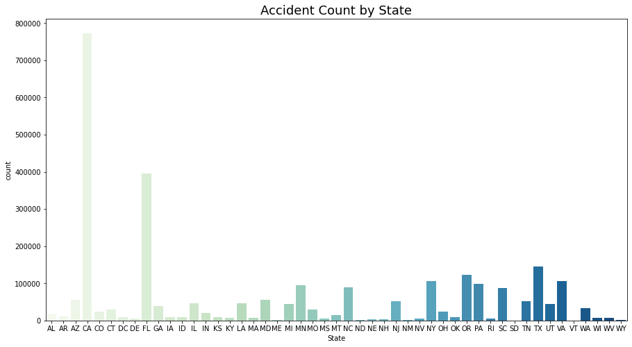

```python
#selecting state and id features and sorting it by state in alphabetical order
hist_states_df = df[["State", "ID"]].sort_values(by="State")

#setting up chart features
plt.figure(figsize=(15,8))
plt.title("Accident Count by State", fontsize=18)

#plot the countplot
hist_states = sns.countplot(x = "State", data = hist_states_df, palette="GnBu");
```

Next, we looked at accident count by month and by day of week to see the accident distribution across different time periods. Interestingly, as shown in the graph, December has the most accident count out of all the Months. We hypothesize that this is due to December being a high season for travelling. Another reason could be due to the winter months causing more traffic accidents due to severe weather. However, that is probably not entirely the case since the months of November - Feburary should have similar weather patterns overall.

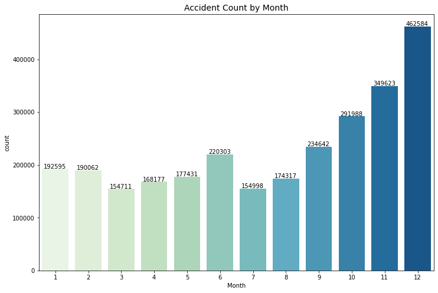

```python
#setting up chart features
plt.figure(figsize=(12,8))
plt.title("Accident Count by Month", fontsize=14)

#plot
g = sns.countplot(x = "Month", data = df,  palette="GnBu")

#plot datapoints
xaxis = np.arange(12)
for i,j in zip(xaxis, df[['ID', 'Month']].groupby(['Month']).count()['ID']):
    g.annotate(str(j), xy=(i - 0.35,j + 1000))
```

The graph below shows that weekdays (Monday - Friday) have the highest number of accident counts. This is something expected because lots of people commute to work or school on the weekdays so the traffic flow is naturally larger on the weekdays, leading to more accidents.

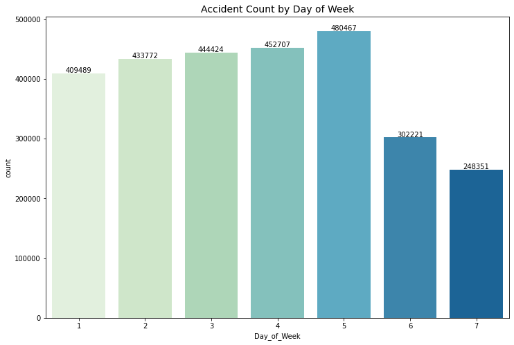

```python
#setting up chart features
plt.figure(figsize=(12,8))
plt.title("Accident Count by Day of Week", fontsize=14)

#plot
g = sns.countplot(x = "Day_of_Week", data = df, palette="GnBu");

#plot datapoints
xaxis = np.arange(7)
for i,j in zip(xaxis, df[['ID', 'Day_of_Week']].groupby(['Day_of_Week']).count()['ID']):
    g.annotate(str(j), xy=(i - 0.2 ,j + 1000))
```

Since our previous graph showed that there are higher accident counts during the weekday vs the weekend and we hypothesize that this could be due to people commuting, we wanted to see the relationship between accident count and hour. As the graph below shows, all of the weekdays (Monday - Friday) follow a similar pattern with most of the accidents happening during the peak hours of 6-8am and 3-6pm, whereas on the weekends, while the general distribution is similar, the curve is a bit less rigid and the accident counts are slightly better distributed throughout the hours.

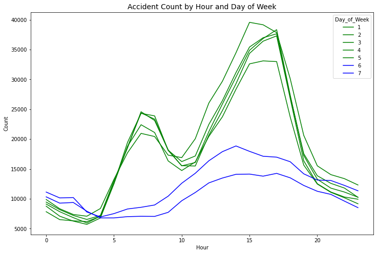

```python
#create a copy of df and add a hour column
hour_df = df
hour_df['Hour'] = hour_df['Start_Time'].dt.hour

#group accident counts by hour and day of week
day_of_week_vs_hour = hour_df[['Hour', 'ID', 'Day_of_Week']].groupby(['Hour', 'Day_of_Week']).count()
day_of_week_vs_hour = day_of_week_vs_hour.rename(columns={'ID' : 'Count'}).reset_index()

#setting up chart features
plt.figure(figsize=(12,8))
plt.title("Accident Count by Hour and Day of Week", fontsize=14)
palette = {1:"green",
           2:"green",
           3:"green",
           4:"green",
           5:"green",
           6:"blue",
           7:"blue"}
#plot
sns.lineplot(data=day_of_week_vs_hour, x="Hour", y="Count", hue="Day_of_Week", palette=palette)
plt.show()
```

## Accidents during the Day vs Night

Another feature we were interested in looking deeper into was daylight. While there would definitely be more accidents that happened during the day since traffic flow is naturally larger during the day, we were interested in seeing how daylight together with weather, obstacle, or other features might influence accident count. For example, we hypothesize that since road visibility is worse at night, perhaps a rainy night would lead to a higher accident percentage than during the day. Similarily, perhaps certain obstacles at night would lead to a higher accident percentage whereas other obstacles during the day would lead to a higher accident percentage.

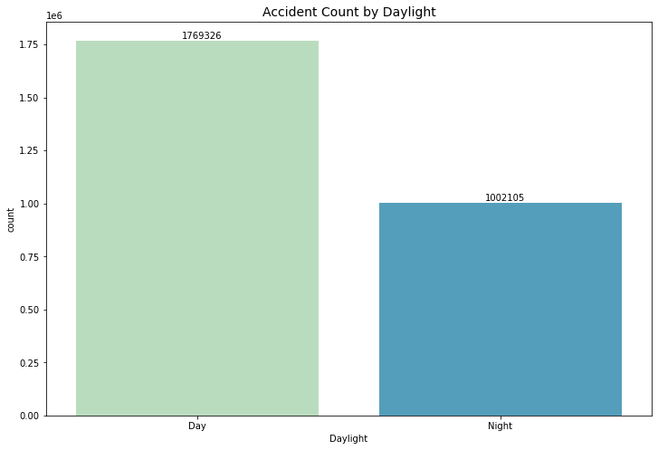

```python
#set up chart features
plt.figure(figsize=(12,8))
plt.title("Accident Count by Daylight", fontsize=14)

#plot accident count by day vs night
g = sns.countplot(x = "Sunrise_Sunset", data = df,  palette="GnBu");
g.set(xlabel='Daylight')
g.set_xticklabels(['Day','Night'])

#plot datapoints
xaxis = np.arange(2)
for i,j in zip(xaxis, df[['ID', 'Sunrise_Sunset']].groupby(['Sunrise_Sunset']).count()['ID']):
    g.annotate(str(j), xy=(i - 0.05 ,j + 10000))

plt.show()
```

### Day vs Night by Weather

The graph below shows the distribution of weather types for accidents happening during the day and during the night. Even though the monthly data doesn't suggest that seaonal weather like snow have a strong impact on the number of accident counts, we are still interested in seeing the relationship between different types of weather, especially how it relates to daylight.

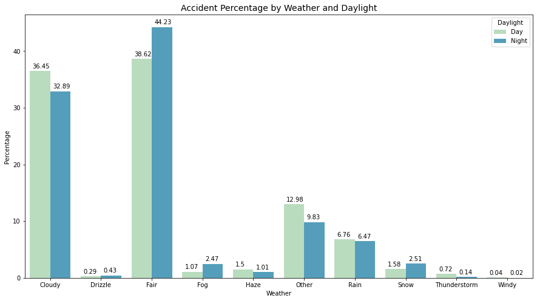

```python
#seperate data into day and night
day_df = df[df['Sunrise_Sunset'] == 0].reset_index()
night_df = df[df['Sunrise_Sunset'] == 1].reset_index()

#creating weather dataset for day
weather_percentage_day = day_df[['Weather_Condition', 'ID']].groupby('Weather_Condition').count().reset_index()
weather_percentage_day = weather_percentage_day.rename(columns={"Weather_Condition": "Weather", "ID" : "Count"})
weather_percentage_day['Percentage'] = round((weather_percentage_day['Count']/ weather_percentage_day['Count'].sum())*100, 2)
weather_percentage_day['Daylight'] = 'Day'

#creating weather dataset for night
weather_percentage_night = night_df[['Weather_Condition', 'ID']].groupby('Weather_Condition').count().reset_index()
weather_percentage_night = weather_percentage_night.rename(columns={"Weather_Condition": "Weather", "ID" : "Count"})
weather_percentage_night['Percentage'] = round((weather_percentage_night['Count']/ weather_percentage_night['Count'].sum())*100, 2)
weather_percentage_night['Daylight'] = 'Night'

#concat the two datasets
weather_percentage = pd.concat([weather_percentage_day, weather_percentage_night], axis=0)

#plot
plt.figure(figsize=(15,8))
g = sns.barplot(x="Weather", y='Percentage', hue="Daylight", data=weather_percentage, palette="GnBu")
plt.title("Accident Percentage by Weather and Daylight", fontsize=14)

#plot datapoints
xaxis = np.arange(10)
for i,j in zip(xaxis, weather_percentage[weather_percentage['Daylight'] == 'Day']['Percentage']):
    g.annotate(str(j), xy=(i - 0.35,j + 0.5))

for i,j in zip(xaxis, weather_percentage[weather_percentage['Daylight'] == 'Night']['Percentage']):
    g.annotate(str(j), xy=(i + 0.05,j + 0.5))

plt.show()
```

As the graph above shows, a large majority of accidents happened on a fair or cloudy day regardless of the time of day, which is something we expected because fair and cloudy are the most frequent types of weather patterns in the U.S. However, if we look closely at how each weather relates to daylight, we see that fair, fog, and snow weather takes up a slightly larger percentage of accidents that happened at night vs during the day.

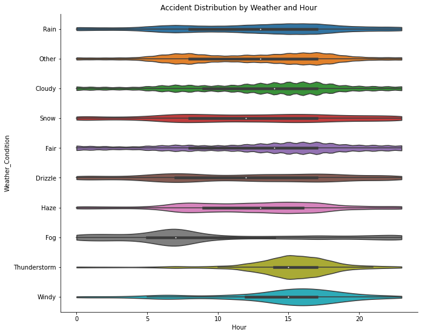

```python
#plot weather condition by hour
weather_plot = sns.catplot(data=df, x="Hour", y="Weather_Condition", kind="violin", cut=0, split=True);
weather_plot.set(title="Accident Distribution by Weather and Hour")
weather_plot.fig.set_figwidth(12)
weather_plot.fig.set_figheight(8)
```

### Day vs Night by Road Features

Aside from weather, we were also interested in looking at how daylight relates to obstacles. The graph below shows the percentage of accidents that happened near an obstacle vs not near an obstacle for all accidents, daytime accidents, and night time accidents. We see that overall, only a quarter of accidents happened near an obstacle, which is again, something that we expected since naturally most accidents just happen on the streets and not necessarily 'near' something. The graph also doesn't seem to show much discrepancy between the distribution for day and night time accidents.

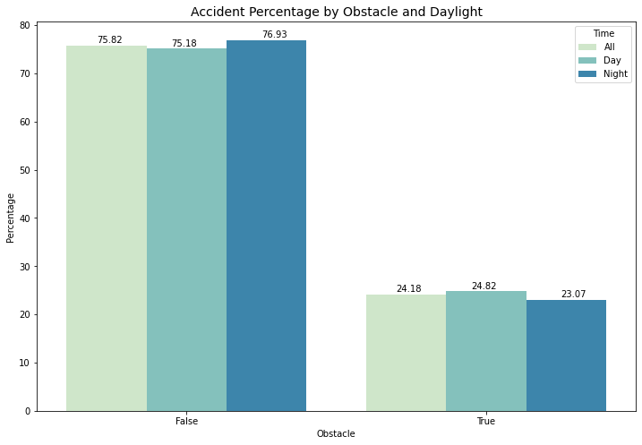

```python
#create obstacle dataset, no obstacle dataset
obstacle_df = df[df['Obstacle'] == 1]
no_obstacle_df = df[df['Obstacle'] == 0]

#calculate % of total accidents that happened near an obstacle vs not
obstacle_percentage = df[['Obstacle', 'ID']].groupby('Obstacle').count().rename(columns={'ID': 'Count'}).reset_index()
obstacle_percentage['Percentage'] = round((obstacle_percentage['Count']/ obstacle_percentage['Count'].sum())*100, 2)
obstacle_percentage['Time'] = 'All'

#calculate % of total daytime accidents that happened near an obstacle vs not
obstacle_percentage_day = day_df[['Obstacle', 'ID']].groupby('Obstacle').count().rename(columns={'ID': 'Count'}).reset_index()
obstacle_percentage_day['Percentage'] = round((obstacle_percentage_day['Count']/ obstacle_percentage_day['Count'].sum())*100, 2)
obstacle_percentage_day['Time'] = 'Day'

#calculate % of total night-time accidents that happened near an obstacle vs not
obstacle_percentage_night = night_df[['Obstacle', 'ID']].groupby('Obstacle').count().rename(columns={'ID': 'Count'}).reset_index()
obstacle_percentage_night['Percentage'] = round((obstacle_percentage_night['Count']/ obstacle_percentage_night['Count'].sum())*100, 2)
obstacle_percentage_night['Time'] = 'Night'

#concat the three dataset together
obstacle_percentage = pd.concat([obstacle_percentage, obstacle_percentage_day, obstacle_percentage_night], axis=0)
obstacle_percentage = obstacle_percentage.replace({0 : 'False', 1 : 'True'})

#set up chart feataures and plot
plt.figure(figsize=(12,8))
plt.title("Accident Percentage by Obstacle and Daylight", fontsize=14)
g = sns.barplot(x="Obstacle", y='Percentage', hue="Time", data=obstacle_percentage, palette="GnBu")

# plot data points
xaxis = np.arange(2)
for i,j in zip(xaxis, obstacle_percentage[obstacle_percentage['Time'] == 'All']['Percentage']):
    g.annotate(str(j), xy=(i - 0.3,j + 0.5))

for i,j in zip(xaxis, obstacle_percentage[obstacle_percentage['Time'] == 'Day']['Percentage']):
    g.annotate(str(j), xy=(i - 0.05,j + 0.5))

for i,j in zip(xaxis, obstacle_percentage[obstacle_percentage['Time'] == 'Night']['Percentage']):
    g.annotate(str(j), xy=(i + 0.25,j + 0.5))

plt.show()
```

If we dig a bit deeper and look at the different types of obstacles and how they relate to daylight, we see that while accidents happening near junctions and stop signs take up a slightly larger percentage of total night time accidents and accidents that happen near traffic signals and crossing take up a slightly larger percentage of total daytime accidents, there isn't much difference between the distributions for daytime and night time accidents. Thus, we don't seem to see much relationship between how road features have an impact on whether an accident is more likely to happen during the day or night.

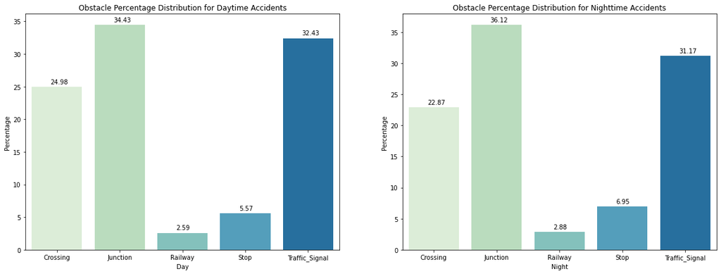

```python
#set up road feature columns that count as an 'obstacle'
columns = ['Crossing','Junction', 'Railway', 'Stop',
                     'Traffic_Signal']

#create df for daytime accidents near obstacle & nightime accidents near obstacle
day_obstacle_df = obstacle_df[obstacle_df['Sunrise_Sunset'] == 0]
night_obstacle_df = obstacle_df[obstacle_df['Sunrise_Sunset'] == 1]

#count the number of accidents by the type of obstacle
obstacle_counts_day = day_obstacle_df[columns].sum().reset_index()
obstacle_counts_day = obstacle_counts_day.rename(columns={0 : 'Count', 'index' : 'Obstacle'})
obstacle_counts_night = night_obstacle_df[columns].sum().reset_index()
obstacle_counts_night = obstacle_counts_night.rename(columns={0 : 'Count', 'index' : 'Obstacle'})

#calculate the percentage of each obstacle type
obstacle_counts_day['Percentage'] = round(obstacle_counts_day['Count']/obstacle_counts_day['Count'].sum()*100, 2)
obstacle_counts_day['Time'] = 'Day'
obstacle_counts_night['Percentage'] = round(obstacle_counts_night['Count']/obstacle_counts_night['Count'].sum()*100, 2)
obstacle_counts_night['Time'] = 'Night'

#plot
fig, axes = plt.subplots(1, 2, figsize=(20, 7))
a = sns.barplot(x = "Obstacle", y= 'Percentage', data= obstacle_counts_day, palette="GnBu", ax=axes[0])
b = sns.barplot(x = "Obstacle", y= 'Percentage', data= obstacle_counts_night, palette="GnBu", ax=axes[1])

# set up chart features
a.set_title("Obstacle Percentage Distribution for Daytime Accidents", fontsize=12)
b.set_title("Obstacle Percentage Distribution for Nighttime Accidents", fontsize=12)
a.set_xlabel("Day")
b.set_xlabel("Night")


# plot data points
xaxis = np.arange(9)
for i,j in zip(xaxis, obstacle_counts_day['Percentage']):
    a.annotate(str(j), xy=(i - 0.1,j + 0.5))

for i,j in zip(xaxis, obstacle_counts_night['Percentage']):
    b.annotate(str(j), xy=(i - 0.1 ,j + 0.5))

plt.show()
```

## Severity Distribution Analysis

In addition to correlation, we are also interested in seeing how accident severity relates to different features. Accident severity is defined as the extent to which an accident impacts the traffic flow. However, as shown by the graph below that shows the accident counts by severity, it's clear that we have an class imbalance in our dataset with most of the accidents having a severity level of 2. This issue was addressed earlier by taking a subsample of the data set for our machine learning models instead of using the imbalanced dataset we have here. For the purpose of EDA, instead of looking at counts, we again took percentages of the different severity to compare the different features.

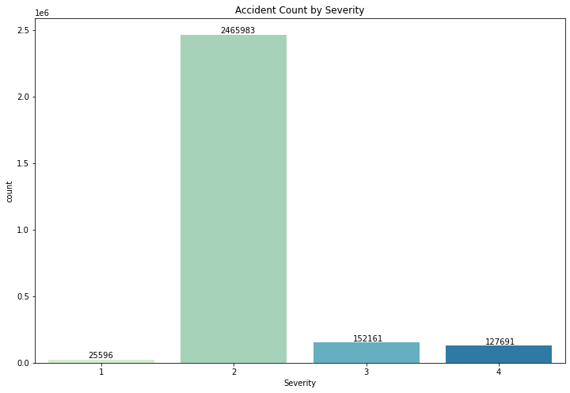

```python
#create severity_df
severity_df = df

# set up chart features and plot
plt.figure(figsize=(12,8))
plt.title("Accident Count by Severity", fontsize=12)
g = sns.countplot(x = "Severity", data = severity_df, palette="GnBu");

#plot data points
xaxis = np.arange(4)
for i,j in zip(xaxis, severity_df[['ID', 'Severity']].groupby(['Severity']).count()['ID']):
    g.annotate(str(j), xy=(i - 0.1,j + 10000))

plt.show()
```

### Severity vs Road Features

```python
#create dataframe for each severity level
one_df = severity_df[severity_df['Severity'] == 1]
two_df = severity_df[severity_df['Severity'] == 2]
three_df = severity_df[severity_df['Severity'] == 3]
four_df = severity_df[severity_df['Severity'] == 4]
```

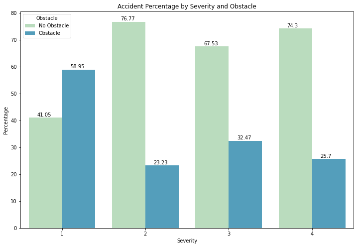

```python
#Find the percentage of obstacle vs no obstacle for accidents with severity level 1
obstacle_severity_one = one_df[['Obstacle', 'ID', 'Severity']].groupby(['Obstacle', 'Severity']).count().reset_index()
obstacle_severity_one = obstacle_severity_one.rename(columns={"ID" : "Count"})
obstacle_severity_one['Percentage'] = round((obstacle_severity_one['Count']/ obstacle_severity_one['Count'].sum())*100, 2)

#Find the percentage of obstacle vs no obstacle for accidents with severity level 2
obstacle_severity_two = two_df[['Obstacle', 'ID', 'Severity']].groupby(['Obstacle', 'Severity']).count().reset_index()
obstacle_severity_two = obstacle_severity_two.rename(columns={"ID" : "Count"})
obstacle_severity_two['Percentage'] = round((obstacle_severity_two['Count']/ obstacle_severity_two['Count'].sum())*100, 2)

#Find the percentage of obstacle vs no obstacle for accidents with severity level 3
obstacle_severity_three = three_df[['Obstacle', 'ID', 'Severity']].groupby(['Obstacle', 'Severity']).count().reset_index()
obstacle_severity_three = obstacle_severity_three.rename(columns={"ID" : "Count"})
obstacle_severity_three['Percentage'] = round((obstacle_severity_three['Count']/ obstacle_severity_three['Count'].sum())*100, 2)

#Find the percentage of obstacle vs no obstacle for accidents with severity level 4
obstacle_severity_four = four_df[['Obstacle', 'ID', 'Severity']].groupby(['Obstacle', 'Severity']).count().reset_index()
obstacle_severity_four = obstacle_severity_four.rename(columns={"ID" : "Count"})
obstacle_severity_four['Percentage'] = round((obstacle_severity_four['Count']/ obstacle_severity_four['Count'].sum())*100, 2)

#Concat the data together and rename columns
obstacle_severity = pd.concat([obstacle_severity_one, obstacle_severity_two, obstacle_severity_three, obstacle_severity_four], axis=0)
obstacle_severity['Obstacle'] = obstacle_severity['Obstacle'].replace({0:'No Obstacle', 1 : 'Obstacle'})

#set up chart features and plot
plt.figure(figsize=(12,8))
g = sns.barplot(x = "Severity", y= 'Percentage', hue = 'Obstacle', data= obstacle_severity, palette="GnBu");
plt.title("Accident Percentage by Severity and Obstacle", fontsize=12)

#plot data points
xaxis = np.arange(4)
for i,j in zip(xaxis, obstacle_severity[obstacle_severity['Obstacle'] == 'No Obstacle']['Percentage']):
    g.annotate(str(j), xy=(i - 0.3,j + 0.5))

for i,j in zip(xaxis, obstacle_severity[obstacle_severity['Obstacle'] == 'Obstacle']['Percentage']):
    g.annotate(str(j), xy=(i + 0.1,j + 0.5))

plt.show()
```

We looked at how the existence vs absence of an obstacle nearby may relate to the severity level of the accident. Interestingly, the distribution is flipped for severity level 1, with the majoriy of the accidents happening near an obstacle. Perhaps this could mean that obstacles such as stop signs, traffic lights, and crossing could've induced the driver to slow down, leading to less severe accidents. Another hypothesis could be that accidents that happen near obstacles are more likely to happen on local roads instead of interstates. This could mean that driving speeds are naturally slower, so the accidents would be less severe. This could also mean that if an accident happens on the interstate vs local roads, accidents on interstates may more easily block the traffic since there is only one road whereas even if an accident happens on a local road, cars have other roads to take and navigate away from the accident. Since severity of an accident is based on how much traffic trouble the accident caused, this could be one of the reasons why severity level 1 has such a high percentage of accidents happening near obstacles.

### Severity vs Time of Day

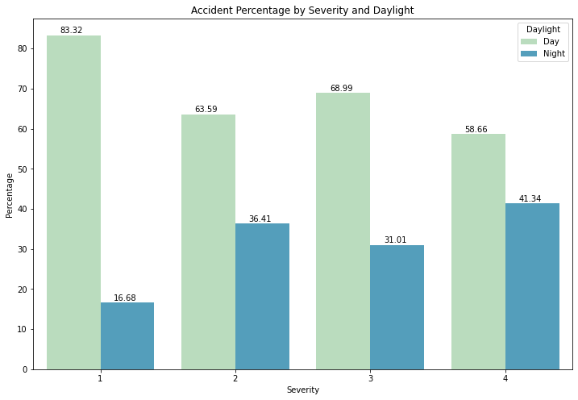

```python
#Find the percentage of day vs night for accidents with severity level 1
daylight_severity_one = one_df[['Sunrise_Sunset', 'ID', 'Severity']].groupby(['Sunrise_Sunset', 'Severity']).count().reset_index()
daylight_severity_one = daylight_severity_one.rename(columns={"Sunrise_Sunset": "Daylight", "ID" : "Count"})
daylight_severity_one['Percentage'] = round((daylight_severity_one['Count']/ daylight_severity_one['Count'].sum())*100, 2)

#Find the percentage of day vs night for accidents with severity level 2
daylight_severity_two = two_df[['Sunrise_Sunset', 'ID', 'Severity']].groupby(['Sunrise_Sunset', 'Severity']).count().reset_index()
daylight_severity_two = daylight_severity_two.rename(columns={"Sunrise_Sunset": "Daylight", "ID" : "Count"})
daylight_severity_two['Percentage'] = round((daylight_severity_two['Count']/ daylight_severity_two['Count'].sum())*100, 2)

#Find the percentage of day vs night for accidents with severity level 3
daylight_severity_three = three_df[['Sunrise_Sunset', 'ID', 'Severity']].groupby(['Sunrise_Sunset', 'Severity']).count().reset_index()
daylight_severity_three = daylight_severity_three.rename(columns={"Sunrise_Sunset": "Daylight", "ID" : "Count"})
daylight_severity_three['Percentage'] = round((daylight_severity_three['Count']/ daylight_severity_three['Count'].sum())*100, 2)

#Find the percentage of day vs night for accidents with severity level 4
daylight_severity_four = four_df[['Sunrise_Sunset', 'ID', 'Severity']].groupby(['Sunrise_Sunset', 'Severity']).count().reset_index()
daylight_severity_four = daylight_severity_four.rename(columns={"Sunrise_Sunset": "Daylight", "ID" : "Count"})
daylight_severity_four['Percentage'] = round((daylight_severity_four['Count']/ daylight_severity_four['Count'].sum())*100, 2)

#Concat the data together and rename columns
daylight_severity = pd.concat([daylight_severity_one, daylight_severity_two, daylight_severity_three, daylight_severity_four], axis=0)
daylight_severity['Daylight'] = daylight_severity['Daylight'].replace({0:'Day', 1 : 'Night'})

#set up chart features and plot
plt.figure(figsize=(12,8))
g = sns.barplot(x = "Severity", y= 'Percentage', hue = 'Daylight', data= daylight_severity, palette="GnBu");
plt.title("Accident Percentage by Severity and Daylight", fontsize=12)

#plot data points
xaxis = np.arange(4)
for i,j in zip(xaxis, daylight_severity[daylight_severity['Daylight'] == 'Day']['Percentage']):
    g.annotate(str(j), xy=(i - 0.3,j + 0.5))

for i,j in zip(xaxis, daylight_severity[daylight_severity['Daylight'] == 'Night']['Percentage']):
    g.annotate(str(j), xy=(i + 0.1,j + 0.5))


plt.show()
```

We also created a simliar graph that compares daylight with severity as we hypothesized that perhaps accidents that happen at night may be more severe due to more people driving over the speed limit at night and poor visibility at night. However, the graph shows otherwise, and that regardless of severity, most accidents still happen during the day. However, we do note that the ratio of accidents happening during the day vs night is the largest for severity one, with only 16% of the accidents that were categorized as severity one happening at night.

### Severity vs Weather

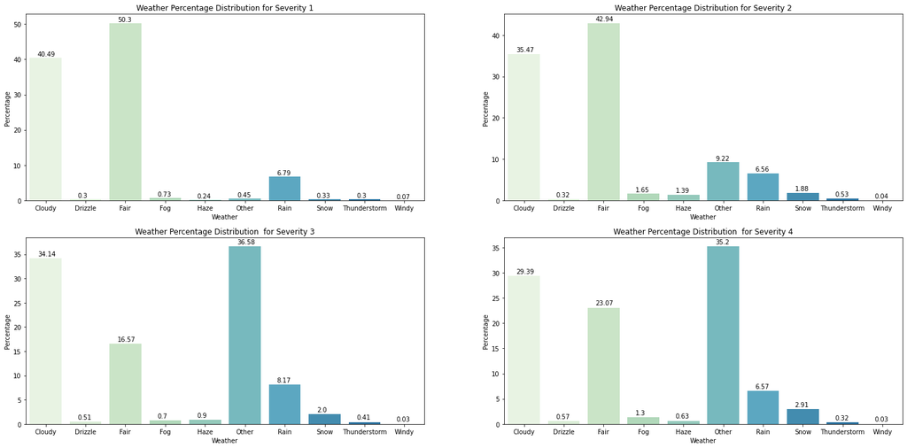

```python
#Find the percentage distribution of different weather types for accidents with severity level 1
weather_severity_one = one_df[['Weather_Condition', 'ID', 'Severity']].groupby(['Weather_Condition', 'Severity']).count().reset_index()
weather_severity_one = weather_severity_one.rename(columns={"Weather_Condition": "Weather", "ID" : "Count"})
weather_severity_one['Percentage'] = round((weather_severity_one['Count']/ weather_severity_one['Count'].sum())*100, 2)

#Find the percentage distribution of different weather types for accidents with severity level 2
weather_severity_two = two_df[['Weather_Condition', 'ID', 'Severity']].groupby(['Weather_Condition', 'Severity']).count().reset_index()
weather_severity_two = weather_severity_two.rename(columns={"Weather_Condition": "Weather", "ID" : "Count"})
weather_severity_two['Percentage'] = round((weather_severity_two['Count']/ weather_severity_two['Count'].sum())*100, 2)

#Find the percentage distribution of different weather types for accidents with severity level 3
weather_severity_three = three_df[['Weather_Condition', 'ID', 'Severity']].groupby(['Weather_Condition', 'Severity']).count().reset_index()
weather_severity_three = weather_severity_three.rename(columns={"Weather_Condition": "Weather", "ID" : "Count"})
weather_severity_three['Percentage'] = round((weather_severity_three['Count']/ weather_severity_three['Count'].sum())*100, 2)

#Find the percentage distribution of different weather types for accidents with severity level 4
weather_severity_four = four_df[['Weather_Condition', 'ID', 'Severity']].groupby(['Weather_Condition', 'Severity']).count().reset_index()
weather_severity_four = weather_severity_four.rename(columns={"Weather_Condition": "Weather", "ID" : "Count"})
weather_severity_four['Percentage'] = round((weather_severity_four['Count']/ weather_severity_four['Count'].sum())*100, 2)

#plot a barplot for each severity levels'
fig, axes = plt.subplots(2, 2, figsize=(25, 12))
a = sns.barplot(x = "Weather", y= 'Percentage', data= weather_severity_one, palette="GnBu", ax=axes[0,0])
b = sns.barplot(x = "Weather", y= 'Percentage', data= weather_severity_two, palette="GnBu", ax=axes[0,1])
c = sns.barplot(x = "Weather", y= 'Percentage', data= weather_severity_three, palette="GnBu", ax=axes[1,0])
d =sns.barplot(x = "Weather", y= 'Percentage', data= weather_severity_four, palette="GnBu", ax=axes[1,1])


# set up chart features and plot
a.set_title("Weather Percentage Distribution for Severity 1", fontsize=12)
b.set_title("Weather Percentage Distribution for Severity 2", fontsize=12)
c.set_title("Weather Percentage Distribution  for Severity 3", fontsize=12)
d.set_title("Weather Percentage Distribution  for Severity 4", fontsize=12)

# plot data points
xaxis = np.arange(10)
for i,j in zip(xaxis, weather_severity_one['Percentage']):
    a.annotate(str(j), xy=(i - 0.2,j + 0.5))

for i,j in zip(xaxis, weather_severity_two['Percentage']):
    b.annotate(str(j), xy=(i - 0.2,j + 0.5))

for i,j in zip(xaxis, weather_severity_three['Percentage']):
    c.annotate(str(j), xy=(i - 0.2,j + 0.5))

for i,j in zip(xaxis, weather_severity_four['Percentage']):
    d.annotate(str(j), xy=(i - 0.2,j + 0.5))

plt.show()
```

Looking at the weather percentage make up for different severity levels, we noticed that severity level 1 and severity level 2 have a more similar weather distribution while severity 3 and 4 have a more similar weather distribution. This could mean that weather has a slight relationship with severity. We see that more than 90% of the weather for severity one is classified as cloudy and fair, whereas for other severity levels, they have a slightly more diverse distribution, especially seen in severity 3 and 4.

### Severity vs Duration

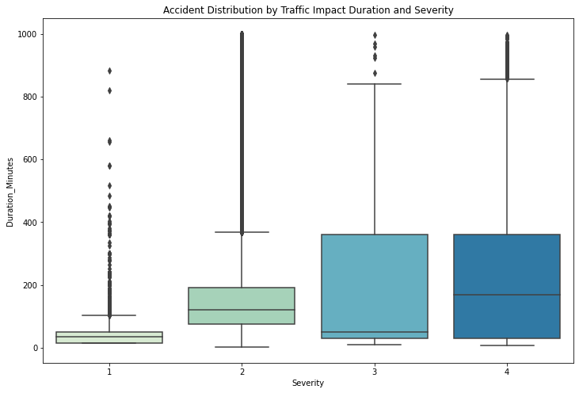

```python
#get duration and severity data
duration_vs_severity = df[['Duration_Minutes', 'Severity']]
duration_vs_severity= duration_vs_severity[(duration_vs_severity['Duration_Minutes'] >= 0) & (duration_vs_severity['Duration_Minutes'] <= 1000)]

#set up chart features and plot
plt.figure(figsize=(12,8))
sns.boxplot(data=duration_vs_severity, x="Severity", y="Duration_Minutes", palette="GnBu")
plt.title("Accident Distribution by Traffic Impact Duration and Severity", fontsize=12)
plt.show()
```

Since accident severity is defined by the extent to which an accident impacts the traffic flow, and duration is a feature that shows the number of minutes traffic was impacted by a certain accident, we were interested in seeing how the two features may relate to each other. Interestingly, it seems like accidents with severity one has the smallest and shortest range for duration, where as the more severe the accident is, the larger ther range for duration.

## Severity Correlation Analysis

We would like to visualize the correlations between the severity of accidents and any other numeric features in our data such as temperature, wind chill, visibility, and etc. It would be useful to know whether there is any strong correlation between a particular feature and the severity of accdients when we do the modeling below.

We started by creating a group of all numeric feature variables from our dataset and Severity, and create a correlation matrix using this dataframe. We used three different methods to calculate correlations - Pearson, Spearman, and Kendall - as we intended to catch any correlations as possible.

### 1. Correlation Heatmap - Pearson

```python
numerics_df = df[['Severity', 'Start_Lat', 'Start_Lng', 'End_Lat', 'End_Lng', 'Distance','Temperature', \
                  'Wind_Chill', 'Humidity', 'Pressure', 'Visibility', 'Wind_Speed', 'Precipitation']]
```

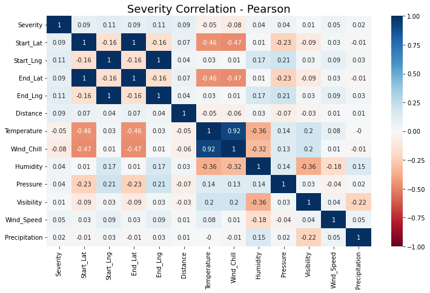

```python
# create a correlation matrix and visualize it using correlation heatmap
corr_matrix = numerics_df.corr(method='pearson').round(2)
plt.figure(figsize=(12, 7))
sns.heatmap(corr_matrix, cmap="RdBu", vmin = -1, vmax = 1, annot=True)
plt.title("Severity Correlation - Pearson", fontsize=18)
plt.show()
```

### 2. Correlation Heatmap - Spearman

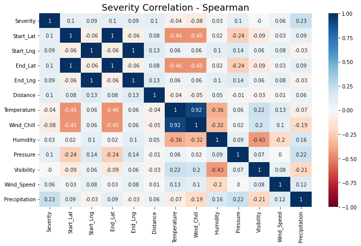

```python
# create a correlation matrix and visualize it using correlation heatmap
corr_matrix = numerics_df.corr(method='spearman').round(2)
plt.figure(figsize=(12, 7))
sns.heatmap(corr_matrix, cmap="RdBu", vmin = -1, vmax = 1, annot=True)
plt.title("Severity Correlation - Spearman", fontsize=18)
plt.show()
```

The same can be concluded using Spearman correlations. The result is similar to what we noticed from the first correlation matrix except for some minor differences in coefficient values.

### 3. Correlation Heatmap - Kendall

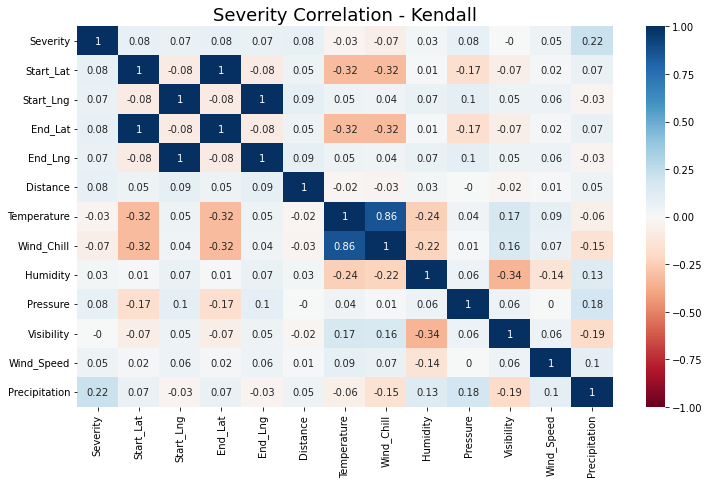

```python
# create a correlation matrix and visualize it using correlation heatmap
corr_matrix = numerics_df.corr(method='kendall').round(2)
plt.figure(figsize=(12, 7))
sns.heatmap(corr_matrix, cmap="RdBu", vmin = -1, vmax = 1, annot=True)
plt.title("Severity Correlation - Kendall", fontsize=18)
plt.show()
```

## Environmental Factor Analysis

### Severity v.s. environment related attributes

Now let's include all other boolean type environmental factors, as well as the year, month, and date information into our correlation matrix, to see if they are related to Severity in some ways. We have previously encoded all boolean attributes in our dataset with 1 (True) and 0 (False) so we can create a correlation matrix with those data here.

```python
# calculate correlations and round up the results to 2 decimals
complete_corr = df.corr().round(2)
complete_corr
```

|  | Severity | Start_Lat | Start_Lng | End_Lat | End_Lng | Distance | Temperature | Wind_Chill | Humidity | Pressure | ... | Sunrise_Sunset | Year | Month | Day | Day_of_Week | Duration_Minutes | Temperature_K | Height | Obstacle | Hour |
| --- | --- | --- | --- | --- | --- | --- | --- | --- | --- | --- | --- | --- | --- | --- | --- | --- | --- | --- | --- | --- | --- |
| Severity | 1.00 | 0.09 | 0.11 | 0.09 | 0.11 | 0.09 | -0.05 | -0.08 | 0.04 | 0.04 | ... | 0.02 | -0.31 | -0.07 | -0.01 | -0.00 | 0.01 | -0.05 | 0.02 | 0.01 | -0.02 |
| Start_Lat | 0.09 | 1.00 | -0.16 | 1.00 | -0.16 | 0.07 | -0.46 | -0.47 | 0.01 | -0.23 | ... | 0.04 | -0.13 | -0.06 | 0.00 | 0.02 | -0.01 | -0.46 | 0.17 | -0.04 | -0.00 |
| Start_Lng | 0.11 | -0.16 | 1.00 | -0.16 | 1.00 | 0.04 | 0.03 | 0.01 | 0.17 | 0.21 | ... | -0.03 | 0.05 | 0.03 | 0.01 | -0.03 | 0.00 | 0.03 | -0.36 | 0.04 | -0.00 |
| End_Lat | 0.09 | 1.00 | -0.16 | 1.00 | -0.16 | 0.07 | -0.46 | -0.47 | 0.01 | -0.23 | ... | 0.04 | -0.13 | -0.06 | 0.00 | 0.02 | -0.01 | -0.46 | 0.17 | -0.04 | -0.00 |
| End_Lng | 0.11 | -0.16 | 1.00 | -0.16 | 1.00 | 0.04 | 0.03 | 0.01 | 0.17 | 0.21 | ... | -0.03 | 0.05 | 0.03 | 0.01 | -0.03 | 0.00 | 0.03 | -0.36 | 0.04 | -0.00 |
| Distance | 0.09 | 0.07 | 0.04 | 0.07 | 0.04 | 1.00 | -0.05 | -0.06 | 0.03 | -0.07 | ... | 0.00 | 0.03 | 0.02 | 0.01 | 0.01 | 0.01 | -0.05 | 0.07 | -0.08 | -0.02 |
| Temperature | -0.05 | -0.46 | 0.03 | -0.46 | 0.03 | -0.05 | 1.00 | 0.92 | -0.36 | 0.14 | ... | -0.34 | 0.03 | 0.07 | 0.00 | -0.01 | -0.00 | 1.00 | -0.11 | 0.04 | 0.17 |
| Wind_Chill | -0.08 | -0.47 | 0.01 | -0.47 | 0.01 | -0.06 | 0.92 | 1.00 | -0.32 | 0.13 | ... | -0.31 | 0.14 | 0.07 | 0.00 | 0.00 | -0.00 | 0.92 | -0.12 | 0.03 | 0.15 |
| Humidity | 0.04 | 0.01 | 0.17 | 0.01 | 0.17 | 0.03 | -0.36 | -0.32 | 1.00 | 0.14 | ... | 0.30 | 0.01 | 0.04 | 0.02 | 0.02 | 0.01 | -0.36 | -0.17 | -0.02 | -0.22 |
| Pressure | 0.04 | -0.23 | 0.21 | -0.23 | 0.21 | -0.07 | 0.14 | 0.13 | 0.14 | 1.00 | ... | -0.02 | -0.18 | -0.02 | -0.02 | -0.03 | 0.01 | 0.14 | -1.00 | 0.05 | -0.02 |
| Visibility | 0.01 | -0.09 | 0.03 | -0.09 | 0.03 | -0.03 | 0.20 | 0.20 | -0.36 | 0.03 | ... | -0.05 | -0.03 | -0.00 | -0.00 | -0.00 | 0.00 | 0.20 | 0.02 | 0.02 | 0.08 |
| Wind_Speed | 0.05 | 0.03 | 0.09 | 0.03 | 0.09 | 0.01 | 0.08 | 0.01 | -0.18 | -0.04 | ... | -0.22 | -0.10 | -0.08 | 0.02 | -0.03 | 0.00 | 0.08 | 0.05 | 0.03 | 0.11 |
| Precipitation | 0.02 | -0.01 | 0.03 | -0.01 | 0.03 | 0.01 | -0.00 | -0.01 | 0.15 | 0.02 | ... | -0.01 | -0.04 | -0.01 | 0.01 | -0.01 | -0.00 | -0.00 | -0.03 | -0.00 | 0.00 |
| Amenity | -0.00 | -0.01 | 0.02 | -0.01 | 0.02 | -0.03 | 0.01 | 0.02 | -0.01 | 0.02 | ... | -0.01 | 0.02 | 0.01 | 0.00 | 0.00 | -0.00 | 0.01 | -0.01 | 0.07 | 0.01 |
| Crossing | -0.04 | -0.10 | 0.06 | -0.10 | 0.06 | -0.09 | 0.07 | 0.07 | -0.03 | 0.02 | ... | -0.02 | 0.04 | 0.01 | 0.00 | -0.01 | -0.00 | 0.07 | 0.01 | 0.49 | 0.02 |
| Junction | 0.05 | 0.04 | -0.02 | 0.04 | -0.02 | 0.02 | -0.02 | -0.04 | 0.01 | 0.05 | ... | -0.00 | -0.16 | -0.03 | -0.00 | -0.02 | 0.00 | -0.02 | -0.05 | 0.60 | -0.02 |
| Railway | -0.00 | 0.00 | -0.01 | 0.00 | -0.01 | -0.02 | 0.00 | 0.00 | -0.00 | 0.02 | ... | 0.00 | -0.00 | -0.00 | -0.00 | 0.00 | 0.00 | 0.00 | -0.01 | 0.16 | -0.00 |
| Station | -0.02 | -0.11 | 0.04 | -0.11 | 0.04 | -0.05 | 0.06 | 0.07 | 0.00 | 0.04 | ... | -0.02 | 0.04 | 0.01 | 0.00 | -0.01 | -0.00 | 0.06 | 0.00 | 0.10 | 0.01 |
| Stop | -0.00 | 0.01 | -0.04 | 0.01 | -0.04 | -0.03 | 0.00 | 0.01 | -0.02 | -0.02 | ... | 0.01 | 0.03 | 0.01 | -0.00 | 0.01 | -0.00 | 0.00 | 0.02 | 0.24 | 0.01 |
| Traffic_Signal | -0.01 | -0.06 | 0.06 | -0.06 | 0.06 | -0.11 | 0.05 | 0.05 | -0.03 | 0.01 | ... | -0.02 | -0.01 | -0.03 | 0.01 | -0.01 | -0.00 | 0.05 | -0.02 | 0.57 | 0.02 |
| Sunrise_Sunset | 0.02 | 0.04 | -0.03 | 0.04 | -0.03 | 0.00 | -0.34 | -0.31 | 0.30 | -0.02 | ... | 1.00 | 0.06 | 0.06 | 0.00 | 0.08 | 0.01 | -0.34 | -0.00 | -0.02 | -0.03 |
| Year | -0.31 | -0.13 | 0.05 | -0.13 | 0.05 | 0.03 | 0.03 | 0.14 | 0.01 | -0.18 | ... | 0.06 | 1.00 | 0.03 | 0.01 | 0.10 | -0.01 | 0.03 | -0.03 | -0.08 | 0.03 |
| Month | -0.07 | -0.06 | 0.03 | -0.06 | 0.03 | 0.02 | 0.07 | 0.07 | 0.04 | -0.02 | ... | 0.06 | 0.03 | 1.00 | 0.03 | -0.01 | 0.01 | 0.07 | 0.02 | -0.03 | 0.04 |
| Day | -0.01 | 0.00 | 0.01 | 0.00 | 0.01 | 0.01 | 0.00 | 0.00 | 0.02 | -0.02 | ... | 0.00 | 0.01 | 0.03 | 1.00 | 0.01 | 0.00 | 0.00 | 0.00 | 0.00 | 0.00 |
| Day_of_Week | -0.00 | 0.02 | -0.03 | 0.02 | -0.03 | 0.01 | -0.01 | 0.00 | 0.02 | -0.03 | ... | 0.08 | 0.10 | -0.01 | 0.01 | 1.00 | -0.00 | -0.01 | 0.01 | -0.02 | -0.00 |
| Duration_Minutes | 0.01 | -0.01 | 0.00 | -0.01 | 0.00 | 0.01 | -0.00 | -0.00 | 0.01 | 0.01 | ... | 0.01 | -0.01 | 0.01 | 0.00 | -0.00 | 1.00 | -0.00 | 0.00 | -0.00 | -0.00 |
| Temperature_K | -0.05 | -0.46 | 0.03 | -0.46 | 0.03 | -0.05 | 1.00 | 0.92 | -0.36 | 0.14 | ... | -0.34 | 0.03 | 0.07 | 0.00 | -0.01 | -0.00 | 1.00 | -0.11 | 0.04 | 0.17 |
| Height | 0.02 | 0.17 | -0.36 | 0.17 | -0.36 | 0.07 | -0.11 | -0.12 | -0.17 | -1.00 | ... | -0.00 | -0.03 | 0.02 | 0.00 | 0.01 | 0.00 | -0.11 | 1.00 | -0.04 | -0.00 |
| Obstacle | 0.01 | -0.04 | 0.04 | -0.04 | 0.04 | -0.08 | 0.04 | 0.03 | -0.02 | 0.05 | ... | -0.02 | -0.08 | -0.03 | 0.00 | -0.02 | -0.00 | 0.04 | -0.04 | 1.00 | 0.01 |
| Hour | -0.02 | -0.00 | -0.00 | -0.00 | -0.00 | -0.02 | 0.17 | 0.15 | -0.22 | -0.02 | ... | -0.03 | 0.03 | 0.04 | 0.00 | -0.00 | -0.00 | 0.17 | -0.00 | 0.01 | 1.00 |

30 rows × 30 columns

Looking for environmental features that are somewhat correlated with the accident severity, we see that there aren't any. There doesn't seem to be any features with correlation values >= 0.5 or <= -0.5.

```python
# find any features with correlation values >= 0.5 or <= -0.5 with Severity
complete_corr.loc[(complete_corr['Severity'] >= 0.5) | (complete_corr['Severity'] <= -0.5)]
```

|  | Severity | Start_Lat | Start_Lng | End_Lat | End_Lng | Distance | Temperature | Wind_Chill | Humidity | Pressure | ... | Sunrise_Sunset | Year | Month | Day | Day_of_Week | Duration_Minutes | Temperature_K | Height | Obstacle | Hour |
| --- | --- | --- | --- | --- | --- | --- | --- | --- | --- | --- | --- | --- | --- | --- | --- | --- | --- | --- | --- | --- | --- |
| Severity | 1.0 | 0.09 | 0.11 | 0.09 | 0.11 | 0.09 | -0.05 | -0.08 | 0.04 | 0.04 | ... | 0.02 | -0.31 | -0.07 | -0.01 | -0.0 | 0.01 | -0.05 | 0.02 | 0.01 | -0.02 |

1 rows × 30 columns

Visualizing the complete correlation matrix, some interesting points worth noting are as follows:

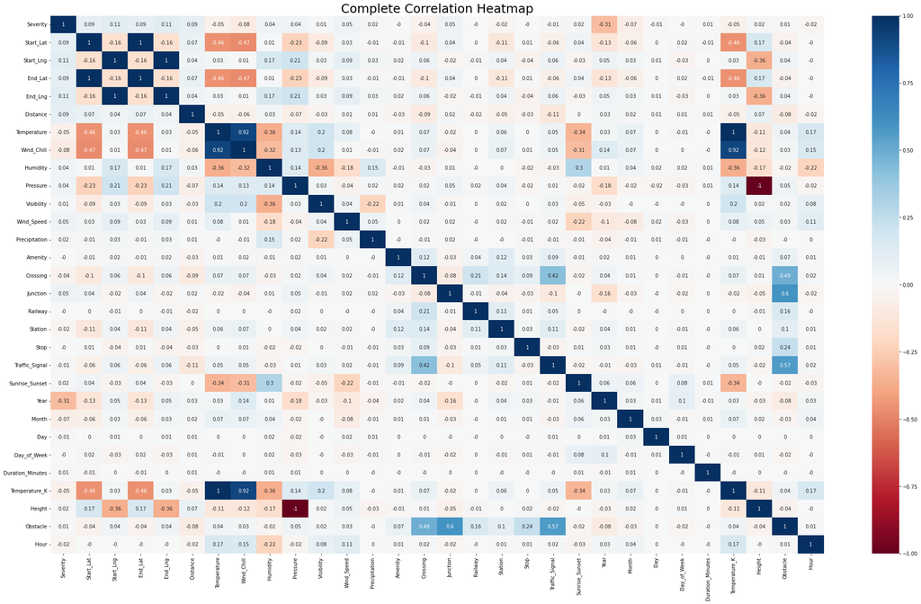

```python
# plot the correlation using correlation heatmap
plt.figure(figsize=(35, 20))
sns.heatmap(complete_corr, cmap="RdBu", vmin = -1, vmax = 1, annot=True)
plt.title("Complete Correlation Heatmap", fontsize=25)
plt.show()
```

### Accident Counts by Quantitative Features

Looking at the distribution of different weather-related quantitative features, for features like temperature where the data varies throughout the year and location, the histogram follows a normal distribution, and for features such as precipitation, pressure, and visibility where there is an expected median level most of the time, the histograms show a clearly skewed graph with the median level having the highest accident count. Thus, it seems like none of the features have a strong impact on accident counts and that the histograms are simply following a distribution of what a typical distribution would look like for the feature in the United States regardless of accident counts.

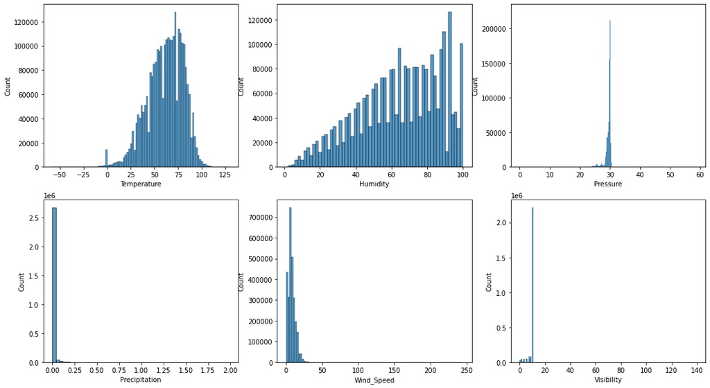

```python
#setup grid chart
fig, axes = plt.subplots(2, 3, figsize=(18, 10))

#plot a histplot for each of the quantitative features
sns.histplot(data=df, x='Temperature', stat='count', bins=100, ax=axes[0,0])
sns.histplot(data=df, x='Humidity', stat='count', bins=60, ax=axes[0,1])
sns.histplot(data=df, x='Pressure', stat='count', bins=1100, ax=axes[0,2])
sns.histplot(data=df, x='Precipitation', stat='count', bins=50, ax=axes[1,0])
sns.histplot(data=df, x='Wind_Speed', stat='count', bins=100, ax=axes[1,1])
sns.histplot(data=df, x='Visibility', stat='count', bins=200, ax=axes[1,2])
plt.show()
```

# Geography-based Analysis

Another fun thing we looked at is the spatial representation of our data. We plotted the accidents per city, and it showed us that the states with the most accidents are Florida and California, which makes sense as the population in both those area are quite high. The city with the highest accident rate is Miami.

```python
#Making a bubble map from longitude latitude coordinates per city based on accidents
df_city_accidents = df[['Start_Lat', 'Start_Lng', 'City', 'ID']]
df_city_accidents = df_city_accidents.groupby('City').agg({'Start_Lat': 'mean', 'Start_Lng': 'mean', 'ID': 'count'})
df_city_accidents = df_city_accidents.reset_index().rename(columns = {'Start_Lat': 'Lat', 'Start_Lng': 'Lng', 'ID':'Accidents'})
df_city_accidents = df_city_accidents.sort_values('Accidents', ascending = False)
```

```python
#Graphing the accidents in a bubble map

df_city_accidents['text'] = df_city_accidents['City'] + '<br>Accidents ' + (df_city_accidents['Accidents']).astype(str)
limits = [(0,3),(4,10),(11,20),(21,50),(50,1000)]
colors = ["blue","royalblue","lightblue","azure","lightgrey"]
cities = []
scale = 50

fig = go.Figure()

for i in range(len(limits)):
    lim = limits[i]
    df_sub = df_city_accidents[lim[0]:lim[1]]
    fig.add_trace(go.Scattergeo(
        locationmode = 'USA-states',
        lon = df_sub['Lng'],
        lat = df_sub['Lat'],
        text = df_sub['text'],
        marker = dict(
            size = df_sub['Accidents']/scale,
            color = colors[i],
            line_color='rgb(40,40,40)',
            line_width=0.5,
            sizemode = 'area'
        ),
        name = '{0} - {1}'.format(lim[0],lim[1])))

fig.update_layout(
        title_text = '2016-2021 US city Accidents<br>(Click legend to toggle traces)',
        showlegend = True,
        geo = dict(
            scope = 'usa',
            landcolor = 'rgb(217, 217, 217)',
        )
    )

fig.show()
```

[interactive chart not shown]

# Machine Learning Models

## Iteration 1

### Choosing the Features

Target: Severity

Features: We first chose the features that we thought were important in finding the model for this dataset. This was chosen from the set of non-categorical values. We wanted to make our first iteration of machine learning simple so we can see which part of the process to improve based on the results of these machine learning models. Remember, this dataset was the dataset extracted from above (during the IMPUTATION section), and the reason why we extracted the subset of data will be apparent below.

1) Start_lng

2) Start_lat

3) Distance

4) Temperature

5) WindChill

6) Humidity

7) Pressure

8) Visibility

9) Wind Speed

10) Precipitation

11) Height

```python
#Set up the List of features we want to use for machine learning models
ml_df = df_for_ml[['Temperature', 'Wind_Chill', 'Humidity', 'Pressure', 'Visibility','Height','Severity','Distance','Wind_Speed', 'Precipitation', 'Start_Lat', 'Start_Lng']]
```

```python
#Set the features vs target arrays
X = ml_df.drop(columns = 'Severity', axis =1)
y = ml_df['Severity']
```

The main reason why we extracted the non-imputed data as the machine learning dataset is twofold:

1) The imputation done on the original dataset is a mean imputation. This meant the data will be more biased towards a specific value and less representative of the true dataset. The original dataset is used for EDA. By doing the KNN imputation here, we can assure that the machine learning model is running on the more accurate dataset.

2) It is VERY expensive to copy the original dataframe without the imputation. Having 2 dataframes with over 2 million datapoints and over 30 features is not ideal for colab. It is more cost efficient to take a subset from the original dataframe to calculate. The good thing here we needed to undersample the overbearing bucket of 2 from the target feature, so taking a subset was the right call.

```python
#KNN Imputation for our data here
imputer = KNNImputer(n_neighbors = 3)
X = imputer.fit_transform(X)
```

```python
#Split the test train dataset with 70-30 split
X_train, X_test, y_train, y_test = train_test_split(X, y , test_size = 0.3)
```

If we look closely at the dataset, we can see that all the units for the chosen machine learning dataset is all different. For example, units of precipitation ranges from 0 to 2, and units of Height can range from 0 to 1000. We thus need to do a standard scale for the dataset. We don't have to worry about scaling catagorical values here, because we didn't choose any categorical values in our first iteration of our machine learning model.

```python
#Standardize the Values
scaler = StandardScaler()
scaler.fit(X_train)
X_train = scaler.transform(X_train)
X_test = scaler.transform(X_test)
```

### PCA Dimensionality Reduction

PCA is also very useful when trying to fix overfitting and run long models. PCA'ed datasets are simpler than its original dataset, thus it'll tend towards less variance and improve the overfitted data. Also, running long models on PCA will always be faster than running models on the original dataset (just because there are less features in the PCA dataset)

#### Ideal components tuning

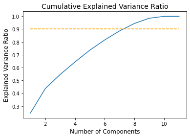

```python
#Finding PCA ideal components
pca = PCA(n_components = X_train.shape[1])
# fit transform scaled features
X_train_2 = pca.fit_transform(X_train)
explained_variance_ratios = pca.explained_variance_ratio_
cum_evr = np.cumsum(explained_variance_ratios)
# Plot (1 point for correct shape)
plt.plot(range(1, len(cum_evr) + 1), cum_evr)
plt.plot(range(1, len(cum_evr) + 1), [0.9] * X_train.shape[1], '--', color = 'orange')

# Aesthetics (1 point for title AND both axes labels)
plt.title("Cumulative Explained Variance Ratio", fontsize=14)
plt.ylabel("Explained Variance Ratio", fontsize=12)
plt.xlabel("Number of Components", fontsize=12)
plt.show()
```

```python
#Inputting the best number of components
# 1. Refit and transform on training with parameter n  (8 seems to keep 0.93 of variance)
pca = PCA(n_components = 8)
X_train_pca = pca.fit_transform(X_train)

# 2. Transform on Testing Set and store it as `x_test_pca`
X_test_pca = pca.transform(X_test)
```

### DummyClassifier

We created some baseline tests with the sklearn dummy classifier library. Each strategy are naive ways of predicting the target. For example, the most_frequent classifier would choose the most frequent label (in this case it would be any of the 4, because they are distributed equally per how we chose the dataset). We use these tests as baselines of what kind of f1/accuracy scores we are shooting for.

```python
#Basic test
strategy = ['most_frequent', 'prior', 'stratified', 'uniform']
scoring_f1 = []
scoring_acc = []

for s in strategy:
    dummy = DummyClassifier(strategy=s, random_state=42)
    dummy = dummy.fit(X_train, y_train)
    y_pred = dummy.predict(X_test)
    scoring_f1.append(metric.f1_score(y_test, y_pred, average='macro'))#We use macro here because we already made the data BALANCED
    scoring_acc.append(metric.accuracy_score(y_test, y_pred))

for i in range(4):
  print(strategy[i].upper())
  print("Best accuracy score: " + str(scoring_acc[i]))
  print("Best F1 score: " + str(scoring_f1[i]))
  print()
```

```
MOST_FREQUENT
Best accuracy score: 0.2476352790796762
Best F1 score: 0.09924185506454479

PRIOR
Best accuracy score: 0.2476352790796762
Best F1 score: 0.09924185506454479

STRATIFIED
Best accuracy score: 0.24797613975287602
Best F1 score: 0.2479630423949128

UNIFORM
Best accuracy score: 0.25675330208777164
Best F1 score: 0.2567758097441142
```

### Logistic Regression Model

Logistic Modeling is the most basic type of modeling for classification. In this case, we want to target the severity of road accidents, which is seperated into 4 classification : 1,2,3, and 4. Each number is how severe the accident is, and is pre determined by the person who created the dataset.

We tuned the hyper parameters with gridsearchCV, where it will check all the possible combinations of the hyperparameters we give it and find the best accuracy score from the model based on a cross validation test. The reason why we use macro here is because according to the sk learn page, macro is best used for balanced datasets. Also, the reason why we only had 1 penalties because lbfgs can only run l2 regularization.

After plugging in the hyperparameters into the model, we get a training score to be 0.44, an accuracy score to be 0.44 and a f1 score to be 0.43. This would indicate underfitting, as it's still predicting only 40% right. However, it is already a significantly better predictor than the dummy classifier.

#### Hyper Parameter Tuning

```python
grid = {'solver': ['newton-cg', 'lbfgs'],
        'penalty': ['l2'],
        'C': [100, 10, 1.0, 0.1, 0.01]}
log_reg = LogisticRegression()
log_reg_GSCV_acc = GridSearchCV(log_reg, grid, cv=5,scoring='accuracy')
log_reg_GSCV_f1 = GridSearchCV(log_reg, grid, cv=5,scoring='f1_macro' )

log_reg_GSCV_acc.fit(X_train, y_train)
log_reg_GSCV_f1.fit(X_train, y_train)

print("Best hyperparameter value (cross val with accuracy): " + str(log_reg_GSCV_acc.best_params_))
print("Best score (cross val with accuracy): " + str(log_reg_GSCV_acc.best_score_))
print()
print("Best hyperparameter value (cross val with f1 score): " + str(log_reg_GSCV_f1.best_params_))
print("Best score (cross val with f1 score): " + str(log_reg_GSCV_f1.best_score_))
```

```
Best hyperparameter value (cross val with accuracy): {'C': 100, 'penalty': 'l2', 'solver': 'newton-cg'}
Best score (cross val with accuracy): 0.44392085609880916

Best hyperparameter value (cross val with f1 score): {'C': 100, 'penalty': 'l2', 'solver': 'newton-cg'}
Best score (cross val with f1 score): 0.4358676297313561
```

#### Refit Logistic Regression Model

```python
#Logistic regression model
log_reg = LogisticRegression(solver='newton-cg', penalty='l2', C=100)
log_reg.fit(X_train, y_train)
y_pred = log_reg.predict(X_test)

print("Best Training Score: " + str(metric.accuracy_score(y_train, log_reg.predict(X_train))))
print("Best accuracy score: " + str(metric.accuracy_score(y_test, y_pred)))
print("Best F1 score: " + str(metric.f1_score(y_test, y_pred, average='macro')))
```

```
Best Training Score: 0.4456740075234652
Best accuracy score: 0.4472092032381764
Best F1 score: 0.4350573697617492
```

#### Hyper Parameter Tuning for PCA model

The biggest thing to note here is that the speed of in which the solution was given was significantly faster than the original dataset(almost 1/3 the time!). This will be important when we try to run machine learning models on bigger datasets.

Also notice the resulting accuracy only dropped by 0.01, which indicates that the reduce in dimensionality was effective in maintaining important information

```python
grid = {'solver': ['newton-cg', 'lbfgs'],
        'penalty': ['l2'],
        'C': [100, 10, 1.0, 0.1, 0.01]}
log_reg = LogisticRegression()
log_reg_GSCV_acc = GridSearchCV(log_reg, grid, cv=5,scoring='accuracy')
log_reg_GSCV_f1 = GridSearchCV(log_reg, grid, cv=5,scoring='f1_macro' )

log_reg_GSCV_acc.fit(X_train_pca, y_train)
log_reg_GSCV_f1.fit(X_train_pca, y_train)

print("Best hyperparameter value (cross val with accuracy): " + str(log_reg_GSCV_acc.best_params_))
print("Best score (cross val with accuracy): " + str(log_reg_GSCV_acc.best_score_))
print()
print("Best hyperparameter value (cross val with f1 score): " + str(log_reg_GSCV_f1.best_params_))
print("Best score (cross val with f1 score): " + str(log_reg_GSCV_f1.best_score_))
```

```
Best hyperparameter value (cross val with accuracy): {'C': 100, 'penalty': 'l2', 'solver': 'newton-cg'}
Best score (cross val with accuracy): 0.4279608877712001

Best hyperparameter value (cross val with f1 score): {'C': 100, 'penalty': 'l2', 'solver': 'newton-cg'}
Best score (cross val with f1 score): 0.41682800003921355
```

#### Refit Logistic Regression Model for PCA

```python
log_reg_pca = LogisticRegression(solver='newton-cg', penalty='l2', C=100)
log_reg_pca.fit(X_train_pca, y_train)
y_pred = log_reg_pca.predict(X_test_pca)

print("Best Training Score: " + str(metric.accuracy_score(y_train, log_reg_pca.predict(X_train_pca))))
print("Best accuracy score: " + str(metric.accuracy_score(y_test, y_pred)))
print("Best F1 score: " + str(metric.f1_score(y_test, y_pred, average='macro')))
```

```
Best Training Score: 0.42905664511887803
Best accuracy score: 0.4343417128248828
Best F1 score: 0.4208943095352338
```

### KNN Model

KNN modeling is a lazy model used to predict classification problems too. What lazy means is that the model memorizes the data instead of actually building a model with weights. This makes it very easy to implement and understand. However, the trade off is that it becomes computationally expensive when it needs to predict something, since it needs to take a poll of all the points around it.

KNN is used here because its another way to model this classification problem. Its also fairly inexpensive to run.

With the only hyperparameter to tune to be neighbors, we find that a n neighbor of 9 is best for our purposes. Notice here we also use a macro scoring for f1 because the data, as said before, is balanced. We will be using macro scoring for f1 for all of the models.

Our result actually surprised us a little. It actually outperformed logistic regression getting a training score of 0.61, an accuracy score of 0.52, and a f1 score of 0.51. Although its a bit overfitted, I think this is still a model worth looking at more closely in the future

#### Hyper Parameters Tuning

2 min

```python
#KNN Parameters
grid = {'n_neighbors': np.arange(1, 10)}
knn = KNeighborsClassifier()
knnGSCV_acc = GridSearchCV(knn, grid, cv=5,scoring='accuracy')
knnGSCV_f1 = GridSearchCV(knn, grid, cv=5,scoring='f1_macro')

knnGSCV_acc.fit(X_train, y_train)
knnGSCV_f1.fit(X_train, y_train)

print("Best hyperparameter value (cross val with accuracy): " + str(knnGSCV_acc.best_params_))
print("Best score (cross val with accuracy): " + str(knnGSCV_acc.best_score_))
print()
print("Best hyperparameter value (cross val with f1 score): " + str(knnGSCV_acc.best_params_))
print("Best score (cross val with f1 score): " + str(knnGSCV_acc.best_score_))
```

```
Best hyperparameter value (cross val with accuracy): {'n_neighbors': 9}
Best score (cross val with accuracy): 0.5179503089685227

Best hyperparameter value (cross val with f1 score): {'n_neighbors': 9}
Best score (cross val with f1 score): 0.5179503089685227
```

#### Refit KNN Model

```python
#KNN with best parameters
knn = KNeighborsClassifier(n_neighbors = 9)
knn.fit(X_train,y_train)
y_pred = knn.predict(X_test)


print("Best Training Score: " + str(metric.accuracy_score(y_train, knn.predict(X_train))))
print("Best accuracy score: " + str(metric.accuracy_score(y_test, y_pred)))
print("Best F1 score: " + str(metric.f1_score(y_test, y_pred, average= 'macro')))
```

```
Best Training Score: 0.6138198020525182
Best accuracy score: 0.5223689816787388
Best F1 score: 0.5112111444135119
```

#### Hyper Parameters Tuning for PCA model

Same as before, we tune the hyperparameters for a KNN model on the PCA training set. We do this because it runs faster than the original dataset and we want to see how much the accuracy dropped by using the PCA set.

It turns out the results barely changed, and the time was also significantly faster!

```python
#KNN Parameters
grid = {'n_neighbors': np.arange(1, 10)}
knn = KNeighborsClassifier()
knnGSCV_acc = GridSearchCV(knn, grid, cv=5,scoring='accuracy')
knnGSCV_f1 = GridSearchCV(knn, grid, cv=5,scoring='f1_macro')

knnGSCV_acc.fit(X_train_pca, y_train)
knnGSCV_f1.fit(X_train_pca, y_train)

print("Best hyperparameter value (cross val with accuracy): " + str(knnGSCV_acc.best_params_))
print("Best score (cross val with accuracy): " + str(knnGSCV_acc.best_score_))
print()
print("Best hyperparameter value (cross val with f1 score): " + str(knnGSCV_acc.best_params_))
print("Best score (cross val with f1 score): " + str(knnGSCV_acc.best_score_))
```

```
Best hyperparameter value (cross val with accuracy): {'n_neighbors': 8}
Best score (cross val with accuracy): 0.512253326314585

Best hyperparameter value (cross val with f1 score): {'n_neighbors': 8}
Best score (cross val with f1 score): 0.512253326314585
```

#### Refit KNN Model for PCA

```python
#KNN with best parameters
knn_pca = KNeighborsClassifier(n_neighbors = 9)
knn_pca.fit(X_train_pca,y_train)
y_pred = knn_pca.predict(X_test_pca)


print("Best Training Score: " + str(metric.accuracy_score(y_train, knn_pca.predict(X_train_pca))))
print("Best accuracy score: " + str(metric.accuracy_score(y_test, y_pred)))
print("Best F1 score: " + str(metric.f1_score(y_test, y_pred, average= 'macro')))
```

```
Best Training Score: 0.6163032759943026
Best accuracy score: 0.5202386024712399
Best F1 score: 0.5092196875755186
```

### Decision Trees Models

The last model considered in this report is a decision tree. A decision tree is a fantastic way to model classification problems. Decision trees are used when there is a non linear boundary between the classes(as oppose to logistic regression where the predictor is a line). However one trouble with a decision tree is that it is prone to over fitting, and the calculations are long.

#### Decision Tree Hyper parameters tuning

3 min

```python
# To Do: Decision Tree tuning
grid = {'splitter' : ['best' , 'random'],
        'max_depth': [None,2, 3, 5, 6, 10],
        'min_samples_leaf': [2, 3, 4, 5],
        'min_samples_split': [2,3, 4, 5]}
decision_tree = DecisionTreeClassifier()
decision_tree_GSCV_acc = GridSearchCV(decision_tree, grid, cv=5, scoring='accuracy')
decision_tree_GSCV_f1 = GridSearchCV(decision_tree, grid, cv=5, scoring='f1_macro')

decision_tree_GSCV_acc.fit(X_train, y_train)
decision_tree_GSCV_f1.fit(X_train, y_train)

print("Best hyperparameter value (cross val with accuracy): " + str(decision_tree_GSCV_acc.best_params_))
print("Best score (cross val with accuracy): " + str(decision_tree_GSCV_acc.best_score_))
print()
print("Best hyperparameter value (cross val with f1 score): " + str(decision_tree_GSCV_f1.best_params_))
print("Best score (cross val with f1 score): " + str(decision_tree_GSCV_f1.best_score_))
```

```
Best hyperparameter value (cross val with accuracy): {'max_depth': 10, 'min_samples_leaf': 5, 'min_samples_split': 2, 'splitter': 'best'}
Best score (cross val with accuracy): 0.6371936004912235

Best hyperparameter value (cross val with f1 score): {'max_depth': 10, 'min_samples_leaf': 2, 'min_samples_split': 4, 'splitter': 'best'}
Best score (cross val with f1 score): 0.634264004203747
```

```python
decision_tree = DecisionTreeClassifier(max_depth= 10, min_samples_leaf= 5, min_samples_split= 5, splitter = 'best')
decision_tree.fit(X_train, y_train)
y_pred = decision_tree.predict(X_test)

print("Best Training Score: " + str(metric.accuracy_score(y_train, decision_tree.predict(X_train))))
print("Best accuracy score: " + str(metric.accuracy_score(y_test, y_pred)))
print("Best F1 score: " + str(metric.f1_score(y_test, y_pred, average = 'macro')))
```

```
Best Training Score: 0.7004492166100581
Best accuracy score: 0.6429484448231785
Best F1 score: 0.638450816757077
```

As we did before, we tried hyperparameters tuning on the pca data to see if the runtime is faster and still maintain a good accuracy. This model actually resulted in a significant decrease in accuracy when trained on the pca data. It resulted in an accuracy of 0.5.

#### Decision tree tuning for pca data

```python
grid = {'splitter' : ['best' , 'random'],
        'max_depth': [None,2, 3, 5, 6, 10],
        'min_samples_leaf': [2, 3, 4, 5],
        'min_samples_split': [2,3, 4, 5]}
decision_tree = DecisionTreeClassifier()
decision_tree_GSCV_acc = GridSearchCV(decision_tree, grid, cv=5, scoring='accuracy')
decision_tree_GSCV_f1 = GridSearchCV(decision_tree, grid, cv=5, scoring='f1_macro')

decision_tree_GSCV_acc.fit(X_train_pca, y_train)
decision_tree_GSCV_f1.fit(X_train_pca, y_train)

print("Best hyperparameter value (cross val with accuracy): " + str(decision_tree_GSCV_acc.best_params_))
print("Best score (cross val with accuracy): " + str(decision_tree_GSCV_acc.best_score_))
print()
print("Best hyperparameter value (cross val with f1 score): " + str(decision_tree_GSCV_f1.best_params_))
print("Best score (cross val with f1 score): " + str(decision_tree_GSCV_f1.best_score_))
```

```
Best hyperparameter value (cross val with accuracy): {'max_depth': 10, 'min_samples_leaf': 2, 'min_samples_split': 2, 'splitter': 'best'}
Best score (cross val with accuracy): 0.48248797381386244

Best hyperparameter value (cross val with f1 score): {'max_depth': 10, 'min_samples_leaf': 2, 'min_samples_split': 3, 'splitter': 'best'}
Best score (cross val with f1 score): 0.47995150952610344
```

```python
decision_tree_pca = DecisionTreeClassifier(max_depth= 10, min_samples_leaf= 2, min_samples_split= 4, splitter = 'best')
decision_tree_pca.fit(X_train_pca, y_train)
y_pred = decision_tree_pca.predict(X_test_pca)

print("Best Training Score: " + str(metric.accuracy_score(y_train, decision_tree_pca.predict(X_train_pca))))
print("Best accuracy score: " + str(metric.accuracy_score(y_test, y_pred)))
print("Best F1 score: " + str(metric.f1_score(y_test, y_pred, average = 'macro')))
```

```
Best Training Score: 0.5527190387494978
Best accuracy score: 0.49032807839795484
Best F1 score: 0.48071089697843633
```

#### Hyper parameters tuning for Random Forest

Unfortunately, instead of the training accuracy and the test accuracy converging, we actually see an even more overfitted graph.

This random forest will not be included in the second iteration because of two things:

1) It over fitted the model even more when its suppose to fix overfitting

2) The model ran for over 30 minutes, making this model very inefficient to run.

The results can be shown below, with a training accuracy of 0.93 and a test accuracy of 0.67.

```python
grid = {'n_estimators': [5, 10, 50, 100],
        'max_features': ['auto', 'sqrt'],
        'max_depth': [None, 5, 10],
        'min_samples_leaf': [3, 5],
        'min_samples_split': [3, 5] }
rand_forest = RandomForestClassifier()
rand_forest_GSCV_acc = GridSearchCV(rand_forest, grid, cv=5, scoring='accuracy')
rand_forest_GSCV_f1 = GridSearchCV(rand_forest, grid, cv=5, scoring='f1_macro')

rand_forest_GSCV_acc.fit(X_train_pca, y_train)
rand_forest_GSCV_f1.fit(X_train_pca, y_train)

print("Best hyperparameter value (cross val with accuracy): " + str(rand_forest_GSCV_acc.best_params_))
print("Best score (cross val with accuracy): " + str(rand_forest_GSCV_acc.best_score_))
print()
print("Best hyperparameter value (cross val with f1 score): " + str(rand_forest_GSCV_f1.best_params_))
print("Best score (cross val with f1 score): " + str(rand_forest_GSCV_f1.best_score_))
```

```
Best hyperparameter value (cross val with accuracy): {'max_depth': None, 'max_features': 'auto', 'min_samples_leaf': 3, 'min_samples_split': 5, 'n_estimators': 100}
Best score (cross val with accuracy): 0.5576860696293805

Best hyperparameter value (cross val with f1 score): {'max_depth': None, 'max_features': 'sqrt', 'min_samples_leaf': 3, 'min_samples_split': 3, 'n_estimators': 100}
Best score (cross val with f1 score): 0.5551526383447319
```

#### Refit Random Forest

```python
rand_forest = RandomForestClassifier(max_depth= None, max_features='sqrt', min_samples_leaf= 3, min_samples_split= 5, n_estimators= 100)
rand_forest.fit(X_train, y_train)
y_pred = rand_forest.predict(X_test)


print("Best Training Score: " + str(metric.accuracy_score(y_train, rand_forest.predict(X_train))))
print("Best accuracy score: " + str(metric.accuracy_score(y_test, y_pred)))
print("Best F1 score: " + str(metric.f1_score(y_test, y_pred, average = 'macro')))
```

```
Best Training Score: 0.9317409882765422
Best accuracy score: 0.6752449936088624
Best F1 score: 0.6718721652478444
```

#### Refit Random Forest to PCA data

The PCA data was not much better as can be seen below. We will not use this classifier in the future.

```python
rand_forest_pca = RandomForestClassifier(max_depth= None, max_features='sqrt', min_samples_leaf= 3, min_samples_split= 5, n_estimators= 100)
rand_forest_pca.fit(X_train_pca, y_train)
y_pred = rand_forest_pca.predict(X_test_pca)


print("Best Training Score: " + str(metric.accuracy_score(y_train, rand_forest_pca.predict(X_train_pca))))
print("Best accuracy score: " + str(metric.accuracy_score(y_test, y_pred)))
print("Best F1 score: " + str(metric.f1_score(y_test, y_pred, average = 'macro')))
```

```
Best Training Score: 0.9509148679741427
Best accuracy score: 0.5666808691947166
Best F1 score: 0.5620500300208635
```

### Results of First Iteration Modeling

From the first iteration, I think the models are already a huge step up from the dummy classifiers mentioned before. We can see that the best performing models are the decision trees resting at around 0.63 for the accuracy. However, there were some models that overfitted like the random forest, KNN, and decision trees, while some are underfitted like logistic regression.

For the next iteration, we plan to fix the over fitted models and the underfitted models with their respective techniques. We will also exclude random forest because it completely overfitted when it was suppose to fix overfitting.

Also, to fix some underfitting on some models, we will be including the categorical values this time, and increase the size of the dataset to 100,000. We expcet this to fix some underfitting issues and perform better.

[figure not shown]

```python
models = ['Baseline: Most Frequent', 'Baseline:  Prior', 'Baseline:  Stratified', 'Baseline:  Uniform',
          'Logistic Regression', 'Logistic Regression PCA', 'KNN', 'KNN PCA', 'Decision Tree', 'Decision Tree PCA',
          'Random Forest', 'Random Forest PCA']


acc = [0.25, 0.25, 0.24, 0.25, 0.44, 0.43, 0.52, 0.51, 0.63, .49, .63, .57]
f1 = [0.1, 0.1, 0.25, 0.25, 0.43, 0.41, 0.51, 0.51, 0.63, .48, .68, .56]


df_dict = {'Accuracy Score': acc, 'F1 Score': f1}
results = pd.DataFrame(data=df_dict, index = models)

xaxis = np.arange(len(models))
width = 0.35

fig, ax = plt.subplots(figsize=(12, 9))

acc = ax.bar(xaxis - width/2, acc, width, label='Accuracy', color = ['Paleturquoise'])
f1 = ax.bar(xaxis + width/2, f1, width, label='F1-score',  color = ['lightseagreen'])


ax.set_xlabel('Models')
ax.set_ylabel('Score Range')
ax.set_title('Classification Scores Received By Each Model')
ax.set_xticks(xaxis, models)
plt.legend()
plt.xticks(xaxis, models)
plt.xticks(rotation = 90)


for i,j in zip(xaxis, results['Accuracy Score']):
    ax.annotate(str(j), xy=(i - 0.35,j+ 0.01))

for i,j in zip(xaxis, results['F1 Score']):
    ax.annotate(str(j), xy=(i+0.03,j+ 0.01))

plt.show()
```

## Iteration 2

### Choosing features

1) Start_lng

2) Start_lat

3) Distance

4) Temperature

5) Humidity

6) Visibility

7) Wind Speed

8) Precipitation

9) Height

10) Obstacle

11) Sunrise_Sunset

12) Crossing

13)Junction

14) Traffic Signal

15) Stop

```python
#Choose the features for the second iteration
ml_df_2_num = df_for_ml_2[['Temperature', 'Humidity', 'Pressure', 'Visibility',
                    'Height','Severity','Distance', 'Precipitation', 'Start_Lat',
                    'Start_Lng']]

X_cat = df_for_ml_2[['Obstacle', 'Sunrise_Sunset', 'Crossing', 'Junction', 'Traffic_Signal', 'Stop']]
```

```python
X_nums = ml_df_2_num.drop(columns = 'Severity', axis =1)
y = ml_df_2_num['Severity']
```

As like before, we will do knn imputation on the missing data here. Note that this will make it more robust than the other dataset

```python
#KNN Imputation for our data here
imputer = KNNImputer(n_neighbors = 3)
X_nums = imputer.fit_transform(X_nums)
```

We must scale ONLY the numerical data and not the categorical binary data. This is because binary values do NOT need to be scaled

```python
# Scale ONLY the numeric data
scaler = StandardScaler()
scaler.fit(X_nums)
X_nums = scaler.transform(X_nums)
```

We need to concatenate the SCALED data with the categorical values. We made a final X with scaled numerical values and the categorical values

```python
df_nums = pd.DataFrame(X_nums)
df_nums.reset_index(drop=True, inplace=True)
X_cat.reset_index(drop=True, inplace=True)
X = pd.concat([df_nums, X_cat], axis=1)
X = X.to_numpy()
```

```python
#Split the test train dataset with 70-30 split
X_train, X_test, y_train, y_test = train_test_split(X, y , test_size = 0.3)
```

### Logistic Regression

Since we already defined the best hyperparameters above, we just need to plug it back into the parameters.

As we can see from the results, the model did indeed improve, if only by 0.03. That means the categorical values did provide some more complexity to the logistic regression model!

```python
#Logistic regression model
log_reg = LogisticRegression(solver='newton-cg', penalty='l2', C=10)
log_reg.fit(X_train, y_train)
y_pred = log_reg.predict(X_test)

print("Best Training Score: " + str(metric.accuracy_score(y_train, log_reg.predict(X_train))))
print("Best accuracy score: " + str(metric.accuracy_score(y_test, y_pred)))
print("Best F1 score: " + str(metric.f1_score(y_test, y_pred, average='macro')))
```

```
Best Training Score: 0.48121904539278565
Best accuracy score: 0.4789159706834839
Best F1 score: 0.4763497157520256
```

### KNN

As we said before, KNN was over fitting in the last iteration. In this iteration, to combat overfitting, we increased the n_neighbor size to 25. This contrast helped the overfitting by quite a bit. Now the difference between the training accuracy and test accuracy is only 0.03, which is a lot smaller than 0.1 in the first iteration. The testing accuracy ALSO improved, showing that this iteration did indeed help.

```python
#KNN with best parameters
knn = KNeighborsClassifier(n_neighbors = 25)
knn.fit(X_train,y_train)
y_pred = knn.predict(X_test)


print("Best Training Score: " + str(metric.accuracy_score(y_train, knn.predict(X_train))))
print("Best accuracy score: " + str(metric.accuracy_score(y_test, y_pred)))
print("Best F1 score: " + str(metric.f1_score(y_test, y_pred, average= 'macro')))
```

```
Best Training Score: 0.6048183265884552
Best accuracy score: 0.5693881029486961
Best F1 score: 0.5620576740204333
```

### Decision Tree

For the decision tree, we used the same parameters found by the gridsearchCV in the first iteration.

With the new dataset, not only was the less overfitted from before (now its only a 0.03 difference), the accuracy core improved by 0.02! This means that the complexity added by the categorical features did help!

```python
decision_tree = DecisionTreeClassifier(max_depth= 10, min_samples_leaf= 5, min_samples_split= 5, splitter = 'best')
decision_tree.fit(X_train, y_train)
y_pred = decision_tree.predict(X_test)

print("Best Training Score: " + str(metric.accuracy_score(y_train, decision_tree.predict(X_train))))
print("Best accuracy score: " + str(metric.accuracy_score(y_test, y_pred)))
print("Best F1 score: " + str(metric.f1_score(y_test, y_pred, average = 'macro')))
```

```
Best Training Score: 0.6886496121086388
Best accuracy score: 0.6604056587693881
Best F1 score: 0.6573818611361897
```

### Results of the Second Iteration

As we can see from this iteration, by adding the categorical values, we were able to get the testing accuracy across the board to go up by around 0.03. By also looking into the different methods to improve overfitting, we were also able to decrease the overfitting in BOTH KNN and the Decision Tree model.

As a result, our best model right now is the decision tree, with an accuracy score of 0.66 and an f1 score of 0.65, which is a stark improvement from the dummy classifiers of 0.25. Note that this dataset is also BALANCED.

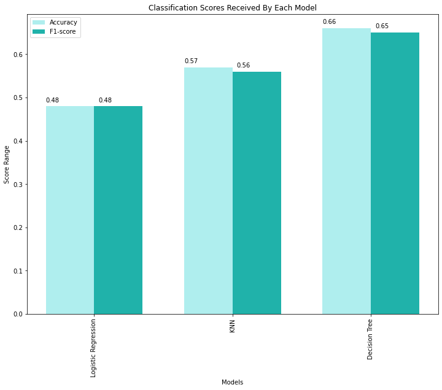

```python
models = ['Logistic Regression', 'KNN', 'Decision Tree']

acc = [0.48, 0.57, 0.66]
f1 = [0.48, 0.56, 0.65]


df_dict = {'Accuracy Score': acc, 'F1 Score': f1}
results = pd.DataFrame(data=df_dict, index = models)

xaxis = np.arange(len(models))
width = 0.35

fig, ax = plt.subplots(figsize=(12, 9))

acc = ax.bar(xaxis - width/2, acc, width, label='Accuracy', color = ['Paleturquoise'])
f1 = ax.bar(xaxis + width/2, f1, width, label='F1-score',  color = ['lightseagreen'])


ax.set_xlabel('Models')
ax.set_ylabel('Score Range')
ax.set_title('Classification Scores Received By Each Model')
ax.set_xticks(xaxis, models)
plt.legend()
plt.xticks(xaxis, models)
plt.xticks(rotation = 90)


for i,j in zip(xaxis, results['Accuracy Score']):
    ax.annotate(str(j), xy=(i - 0.35,j+ 0.01))

for i,j in zip(xaxis, results['F1 Score']):
    ax.annotate(str(j), xy=(i+0.03,j+ 0.01))

plt.show()
```

# Conclusion

## EDA

From the exploratory data analysis, we were able to better understand our dataset and gain some insights about traffic accidents in the United States.

First, we saw that California and Florida had the most number of accidents out of all the states and that December had the most number of accidents out of all the months. We also saw how time of the day and day of the week relates to accident counts, with the rush hour times having drastically more accidents. These findings reiterate the fact that higher traffic flows naturally leads to more traffic accidents, and while there may be other factors like visibility, weather, or road features that could impact traffic accident frequency, ultimately, the biggest influencing factor is the amount of traffic on the road.

Looking at other factors like daylight, weather, road features and how they relate to the count and severity of traffic accidents, we saw that while weather by itself doesn’t seem to have a strong impact on the number of traffic accidents, certain weather such as snow when combined with poor visibility at night could potentially increase the chance of a traffic accident. Additionally, while weather might not have a strong impact on increasing or decreasing accident counts, it appears to have a slight relationship with the severity of accidents seeing that severity 1 and 2 accidents follow a similar weather pattern distribution whereas severity 3 and 4 have a more similar distribution. We also found that the majority of the accidents with a severity level 1 happened near an obstacle, which suggests that certain road features may influence the severity level of accidents. However, the same cannot be said about the relationship between obstacles and weather or time of day, since we couldn't find any conclusive relationship in our EDA.

Overall, while there are some minimal insights from our EDA portion, it seems as if many of the features are intercorrelated with each other, and that there isn’t one specific feature that has a great impact on accident count or severity level.

Taking a further look at the correlation heatmap further demonstrates that there isn’t one specific feature that relates to severity level of the accidents. The features that show a strong correlation in our heatmap are features that are inherently related to one another such as longitude and latitude, traffic signal and crossing, and height and pressure. Thus, while we were able to find some relationships between our features, we weren’t able to find any clear relationship between how a feature may impact the severity of accidents.

## Modeling

From the modeling data, we could see that there are stark improvements in the modeling that we did. From the beginning, we had a dummy classifier that had an accuracy score of 0.25, which makes sense because the labels in the target feature is evenly divided up by 4. By doing two iterations with different number of data points and different parameters, we came to the conclusion below:

- Logistic Regression: The first result of logistic regression returned an accuracy score of 0.44 and a f1 score of 0.43. This is a bit better than just randomly guessing, but its still severely underfitted. To improve our score, we used more data points in the second iteration and also 6 new categorical features that added to the complexity of the model. We can see an improvement in the second iteration where the accuracy score is 0.48 and the f1 score is also 0.48.
- KNN: The first result of KNN returned an accuracy score of 0.52 and an f1 score of 0.51. However, it also had a training accuracy of 0.62, which means the model is overfitting. However, we cannot deny that this model outperform logistic regression by a bit. To fix the overfitting in the model, our second iteration called for the n_neighbors to be higher. Increasing n_neighbors will decrease the noise that comes from small nearest neighbor values. Also including the categorical data means the model will be more complex. We found that the second iteration did indeed improve the model to a 0.57 accuracy and 0.56 f1 score with the training accuracy dropping to 0.6.
- Decision Trees: The initial result of decsion trees was a 0.63 accuracy score and a 0.63 f1 score. However, this came with a training accuracy of 0.69, which proved to be a little overfitted. To combat this overfitting, we tried to use random forest, but unfortunately got a result that was even more overfitted (training: 0.93 test: 0.68). For our second iteration of Decision Trees, we have new categorical data that helped smooth out the overfittedness of our original model, and end up with the best score of 0.66 testing accuracy and 0.65 f1 score.

## Future Directions

There are quite a few directions this project can go from here, however, some of the biggest improvements this project can make are listed below:

- Forward Feed Neural Network: A neural network is definitely possible with this dataset, especially with a dataset this big. A neural net would help with the overall underfitting of the models in this project. However, we do have to watch out for the computing power and the time it takes to run a neural network. Otherwise, a neural network would be a great addition to this project.
- Gathering more data: Another way to solve the overall underfitted models in our project (to increase complexity) is to include more features in our dataset to run the machine learning models on. We could potentially find other datasets such as car density in each city as one of the features or the even the type of car that was in the accident. All these new features can add to the complexity of the model and help it get a better accuracy and f1 score
- Better Hardware/Optimized Code: A problem we repeatedly encountered in this project was the fact that colab would keep crashing on us because there isn't enough RAM. We made some adjustments in the project like sampling only a small subset of data to be used in machine learning. However, with more RAM or a more optimized code, we would not have to worry about that.
- A prediction tool: We could potentially even turn this project into a detection tool for predicting accidents in certain cities near certain features. This would require a lot more domain knowledge and more up to date data from around the US.